# EJP-Soil Fungi data analyse

Sam Lambrechts

Silke De Backer

2024-03-26

# 1 Inlezen data

```r
path_naar_bestand <- file.path(
    ejp_folder,
    "Bodem_biodiversiteit",
    "03_resultaten",
    "phyloseq",
    "Fungi",
    "SRS",
    "met_otuxx",
    "physeq_SRS_Fungi_fungi_species.Rdata"
  )

load(path_naar_bestand)

SRS_fungi_species <- physeq_fungi_fungi.species

rm(physeq_fungi_fungi.species)

path_naar_bestand2 <- file.path(
    ejp_folder,
    "Bodem_biodiversiteit",
    "03_resultaten",
    "phyloseq",
    "Fungi",
    "met_otuxx",
    "physeq_fungi_fungi.Rdata"
  )

load(path_naar_bestand2)

path_naar_bestand3 <- file.path(
    ejp_folder,
    "Bodem_biodiversiteit",
    "03_resultaten",
    "phyloseq",
    "Fungi",
    "met_otuxx",
    "physeq_fungi_fungi_species.Rdata"
  )

load(path_naar_bestand3)
```

Het bestand dat wordt ingelezen is physeq_SRS_Fungi_fungi_species.Rdata en physeq_fungi_fungi.Rdata en physeq_fungi_fungi_species.Rdata.

# 2 Preprocessing stappen, Filter en Selectie

```r
# rename physeq objects and remove samples from Gontrode (different project) en litter layer

physeq_srs <- SRS_fungi_species
physeq_nonrarefied <- physeq_fungi_fungi
physeq_nonrarefied_merged <- physeq_fungi_fungi.species

physeq_srs <- subset_samples_no_zero(physeq_srs, Location != "Gontrode")
physeq_nonrarefied <- subset_samples_no_zero(physeq_nonrarefied, Location != "Gontrode")
physeq_nonrarefied_merged <- subset_samples_no_zero(physeq_nonrarefied_merged, Location != "Gontrode")

physeq_srs <- subset_samples_no_zero(physeq_srs, Protocol2 != "litter")
physeq_nonrarefied <- subset_samples_no_zero(physeq_nonrarefied, Protocol2 != "litter")
physeq_nonrarefied_merged <- subset_samples_no_zero(physeq_nonrarefied_merged, Protocol2 != "litter")

# remove singetons from physeq srs

taxa_sums <- taxa_sums(physeq_srs)

singletons <- names(taxa_sums[taxa_sums == 1])

empty_otus <- names(taxa_sums[taxa_sums == 0])

physeq_srs <- prune_taxa(!(taxa_names(physeq_srs) %in% singletons), physeq_srs)

# remove singletons from physeq nonrarefied

taxa_sums <- taxa_sums(physeq_nonrarefied)

singletons <- names(taxa_sums[taxa_sums == 1])

empty_otus <- names(taxa_sums[taxa_sums == 0])

physeq_nonrarefied <- prune_taxa(!(taxa_names(physeq_nonrarefied) %in% singletons), physeq_nonrarefied)

# remove singetons from physeq nonrarefied merged

taxa_sums <- taxa_sums(physeq_nonrarefied_merged)

singletons <- names(taxa_sums[taxa_sums == 1])

empty_otus <- names(taxa_sums[taxa_sums == 0])

physeq_nonrarefied_merged <- prune_taxa(!(taxa_names(physeq_nonrarefied_merged) %in% singletons), physeq_nonrarefied_merged)

# create phyloseq objects with only known taxa

physeq_known_species <- subset_taxa(physeq_nonrarefied_merged, !grepl("_otu", tax_table(physeq_nonrarefied_merged)[, "Species"]))
physeq_known_genera <- subset_taxa(physeq_nonrarefied_merged, !grepl("_otu", tax_table(physeq_nonrarefied_merged)[, "Genus"]))
physeq_known_order <- subset_taxa(physeq_nonrarefied_merged, !grepl("_otu", tax_table(physeq_nonrarefied_merged)[, "Order"]))
physeq_known_family <- subset_taxa(physeq_nonrarefied_merged, !grepl("_otu", tax_table(physeq_nonrarefied_merged)[, "Family"]))
physeq_known_class <- subset_taxa(physeq_nonrarefied_merged, !grepl("_otu", tax_table(physeq_nonrarefied_merged)[, "Class"]))

physeq_srs_known_species <- subset_taxa(physeq_srs, !grepl("_otu", tax_table(physeq_srs)[, "Species"]))
physeq_srs_known_genera <- subset_taxa(physeq_srs, !grepl("_otu", tax_table(physeq_srs)[, "Genus"]))
physeq_srs_known_order <- subset_taxa(physeq_srs, !grepl("_otu", tax_table(physeq_srs)[, "Order"]))
physeq_srs_known_family <- subset_taxa(physeq_srs, !grepl("_otu", tax_table(physeq_srs)[, "Family"]))
physeq_srs_known_class <- subset_taxa(physeq_srs, !grepl("_otu", tax_table(physeq_srs)[, "Class"]))
```

```r
sample_sums(physeq_nonrarefied)
```

```
##         Bredene_0_10        Bredene_10_30        Bredene_Lucas
##                 8623                 9614                 7623
##        Burdinne_0_10       Burdinne_10_30       Burdinne_Lucas
##                 3206                 7815                 7864
##     Cerfontaine_0_10    Cerfontaine_10_30    Cerfontaine_Lucas
##                 8875                 8885                 4742
##          Deurne_0_10         Deurne_10_30      Diepenbeek_0_10
##                  561                 7768                 9373
##     Diepenbeek_10_30     Diepenbeek_Lucas Diepenbeek_strooisel
##                18103                13721                 7946
##         Genappe_0_10        Genappe_10_30        Genappe_Lucas
##                14997                 8063                 8380
##       Herentals_0_10      Herentals_10_30           Marke_0_10
##                 7117                12347                 8945
##          Marke_10_30          Marke_Lucas       Molenbeek_0_10
##                 6435                 6477                 8739
##      Molenbeek_10_30      Molenbeek_Lucas         Seneffe_0_10
##                 2536                 5782                 7946
##      Seneffe_10_30_1        Seneffe_Lucas     Sombreffe_0_10_1
##                 8380                 1855                10347
##      Sombreffe_10_30      Sombreffe_Lucas
##                 6453                 5990
```

```r
sample_sums(physeq_nonrarefied_merged)
```

```
##         Bredene_0_10        Bredene_10_30        Bredene_Lucas
##                 8623                 9614                 7623
##        Burdinne_0_10       Burdinne_10_30       Burdinne_Lucas
##                 3206                 7815                 7864
##     Cerfontaine_0_10    Cerfontaine_10_30    Cerfontaine_Lucas
##                 8875                 8885                 4742
##          Deurne_0_10         Deurne_10_30      Diepenbeek_0_10
##                  561                 7768                 9373
##     Diepenbeek_10_30     Diepenbeek_Lucas Diepenbeek_strooisel
##                18104                13722                 7948
##         Genappe_0_10        Genappe_10_30        Genappe_Lucas
##                14998                 8063                 8380
##       Herentals_0_10      Herentals_10_30           Marke_0_10
##                 7117                12347                 8945
##          Marke_10_30          Marke_Lucas       Molenbeek_0_10
##                 6435                 6478                 8739
##      Molenbeek_10_30      Molenbeek_Lucas         Seneffe_0_10
##                 2536                 5783                 7946
##      Seneffe_10_30_1        Seneffe_Lucas     Sombreffe_0_10_1
##                 8380                 1855                10348
##      Sombreffe_10_30      Sombreffe_Lucas
##                 6453                 5990
```

```r
sample_sums(physeq_srs)
```

```
##         Bredene_0_10        Bredene_10_30        Bredene_Lucas
##                 1832                 1831                 1823
##        Burdinne_0_10       Burdinne_10_30       Burdinne_Lucas
##                 1825                 1841                 1837
##     Cerfontaine_0_10    Cerfontaine_10_30    Cerfontaine_Lucas
##                 1824                 1825                 1815
##         Deurne_10_30      Diepenbeek_0_10     Diepenbeek_10_30
##                 1778                 1801                 1837
##     Diepenbeek_Lucas Diepenbeek_strooisel         Genappe_0_10
##                 1844                 1743                 1851
##        Genappe_10_30        Genappe_Lucas       Herentals_0_10
##                 1822                 1835                 1806
##      Herentals_10_30           Marke_0_10          Marke_10_30
##                 1806                 1794                 1807
##          Marke_Lucas       Molenbeek_0_10      Molenbeek_10_30
##                 1806                 1826                 1812
##      Molenbeek_Lucas         Seneffe_0_10      Seneffe_10_30_1
##                 1818                 1817                 1828
##        Seneffe_Lucas     Sombreffe_0_10_1      Sombreffe_10_30
##                 1841                 1842                 1829
##      Sombreffe_Lucas
##                 1843
```

## 2.1 Conversie voor gebruik in andere packages

Voorbereidende stap: functies om een `phyloseq` object te converteren naar een `vegan matrix` of een `tidytacos` object.

```r
psotu2veg <- function(physeq_srs) {
  otu <- phyloseq::otu_table(physeq_srs)
  if (phyloseq::taxa_are_rows(otu)) {
    otu <- t(otu)
  }
  return(as(otu, "matrix"))
}

veganobject_physeq_srs <- psotu2veg(physeq_srs)
```

```r
psotu2veg <- function(physeq_nonrarefied) {
  otu <- phyloseq::otu_table(physeq_nonrarefied)
  if (phyloseq::taxa_are_rows(otu)) {
    otu <- t(otu)
  }
  return(as(otu, "matrix"))
}

veganobject_physeq_nonrarefied <- psotu2veg(physeq_nonrarefied)
```

```r
psotu2veg <- function(physeq_nonrarefied_merged) {
  otu <- phyloseq::otu_table(physeq_nonrarefied_merged)
  if (phyloseq::taxa_are_rows(otu)) {
    otu <- t(otu)
  }
  return(as(otu, "matrix"))
}

veganobject_physeq_nonrarefied_merged <- psotu2veg(physeq_nonrarefied_merged)
```

```r
tidy_physeq_srs <- tidytacos::from_phyloseq(physeq_srs)
tidy_physeq_nonrarefied <- tidytacos::from_phyloseq(physeq_nonrarefied)
tidy_physeq_nonrarefied_merged <- tidytacos::from_phyloseq(physeq_nonrarefied_merged)
tidy_physeq_known_species <- tidytacos::from_phyloseq(physeq_known_species)
tidy_physeq_known_genera <- tidytacos::from_phyloseq(physeq_known_genera)
tidy_physeq_known_family <- tidytacos::from_phyloseq(physeq_known_family)
tidy_physeq_known_order <- tidytacos::from_phyloseq(physeq_known_order)
tidy_physeq_known_class <- tidytacos::from_phyloseq(physeq_known_class)
tidy_physeq_srs_known_species <- tidytacos::from_phyloseq(physeq_srs_known_species)
tidy_physeq_srs_known_genera <- tidytacos::from_phyloseq(physeq_srs_known_genera)
tidy_physeq_srs_known_family <- tidytacos::from_phyloseq(physeq_srs_known_family)
tidy_physeq_srs_known_order <- tidytacos::from_phyloseq(physeq_srs_known_order)
tidy_physeq_srs_known_class <- tidytacos::from_phyloseq(physeq_srs_known_class)
tidy_physeq_srs <- tidy_physeq_srs %>%
  remove_empty_samples() %>%
  tidytacos::set_rank_names(
    rank_names = c("phylum", "class", "order", "family", "genus", "species")
  ) %>%
  tidytacos::add_alpha() %>%
  tidytacos::add_total_count()


tidy_physeq_nonrarefied <- tidy_physeq_nonrarefied %>%
  remove_empty_samples() %>%
  tidytacos::set_rank_names(
    rank_names = c("phylum", "class", "order", "family", "genus", "species")
  ) %>%
  tidytacos::add_alpha() %>%
  tidytacos::add_total_count()

tidy_physeq_nonrarefied_merged <- tidy_physeq_nonrarefied_merged %>%
  remove_empty_samples() %>%
  tidytacos::set_rank_names(
    rank_names = c("phylum", "class", "order", "family", "genus", "species")
  ) %>%
  tidytacos::add_alpha() %>%
  tidytacos::add_total_count()


tidy_physeq_known_species <- tidy_physeq_known_species %>%
  remove_empty_samples() %>%
  tidytacos::set_rank_names(
    rank_names = c("phylum", "class", "order", "family", "genus", "species")
  ) %>%
  tidytacos::add_alpha() %>%
  tidytacos::add_total_count()

tidy_physeq_known_genera <- tidy_physeq_known_genera %>%
  remove_empty_samples() %>%
  tidytacos::set_rank_names(
    rank_names = c("phylum", "class", "order", "family", "genus", "species")
  ) %>%
  tidytacos::add_alpha() %>%
  tidytacos::add_total_count()

tidy_physeq_known_family <- tidy_physeq_known_family %>%
  remove_empty_samples() %>%
  tidytacos::set_rank_names(
    rank_names = c("phylum", "class", "order", "family", "genus", "species")
  ) %>%
  tidytacos::add_alpha() %>%
  tidytacos::add_total_count()

tidy_physeq_known_order <- tidy_physeq_known_order %>%
  remove_empty_samples() %>%
  tidytacos::set_rank_names(
    rank_names = c("phylum", "class", "order", "family", "genus", "species")
  ) %>%
  tidytacos::add_alpha() %>%
  tidytacos::add_total_count()

tidy_physeq_known_class <- tidy_physeq_known_class %>%
  remove_empty_samples() %>%
  tidytacos::set_rank_names(
    rank_names = c("phylum", "class", "order", "family", "genus", "species")
  ) %>%
  tidytacos::add_alpha() %>%
  tidytacos::add_total_count()



tidy_physeq_srs_known_species <- tidy_physeq_srs_known_species %>%
  remove_empty_samples() %>%
  tidytacos::set_rank_names(
    rank_names = c("phylum", "class", "order", "family", "genus", "species")
  ) %>%
  tidytacos::add_alpha() %>%
  tidytacos::add_total_count()

tidy_physeq_srs_known_genera <- tidy_physeq_srs_known_genera %>%
  remove_empty_samples() %>%
  tidytacos::set_rank_names(
    rank_names = c("phylum", "class", "order", "family", "genus", "species")
  ) %>%
  tidytacos::add_alpha() %>%
  tidytacos::add_total_count()

tidy_physeq_srs_known_family <- tidy_physeq_srs_known_family %>%
  remove_empty_samples() %>%
  tidytacos::set_rank_names(
    rank_names = c("phylum", "class", "order", "family", "genus", "species")
  ) %>%
  tidytacos::add_alpha() %>%
  tidytacos::add_total_count()

tidy_physeq_srs_known_order <- tidy_physeq_srs_known_order %>%
  remove_empty_samples() %>%
  tidytacos::set_rank_names(
    rank_names = c("phylum", "class", "order", "family", "genus", "species")
  ) %>%
  tidytacos::add_alpha() %>%
  tidytacos::add_total_count()

tidy_physeq_srs_known_class <- tidy_physeq_srs_known_class %>%
  remove_empty_samples() %>%
  tidytacos::set_rank_names(
    rank_names = c("phylum", "class", "order", "family", "genus", "species")
  ) %>%
  tidytacos::add_alpha() %>%
  tidytacos::add_total_count()
```

# 3 Verkennende analyses

```r
physeq_nonrarefied
```

```
## phyloseq-class experiment-level object
## otu_table()   OTU Table:         [ 3391 taxa and 32 samples ]
## sample_data() Sample Data:       [ 32 samples by 25 sample variables ]
## tax_table()   Taxonomy Table:    [ 3391 taxa by 7 taxonomic ranks ]
```

```r
physeq_nonrarefied_merged
```

```
## phyloseq-class experiment-level object
## otu_table()   OTU Table:         [ 3248 taxa and 32 samples ]
## sample_data() Sample Data:       [ 32 samples by 25 sample variables ]
## tax_table()   Taxonomy Table:    [ 3248 taxa by 7 taxonomic ranks ]
```

```r
physeq_srs
```

```
## phyloseq-class experiment-level object
## otu_table()   OTU Table:         [ 1423 taxa and 31 samples ]
## sample_data() Sample Data:       [ 31 samples by 25 sample variables ]
## tax_table()   Taxonomy Table:    [ 1423 taxa by 7 taxonomic ranks ]
```

```r
physeq_known_species
```

```
## phyloseq-class experiment-level object
## otu_table()   OTU Table:         [ 496 taxa and 32 samples ]
## sample_data() Sample Data:       [ 32 samples by 25 sample variables ]
## tax_table()   Taxonomy Table:    [ 496 taxa by 7 taxonomic ranks ]
```

```r
physeq_known_genera
```

```
## phyloseq-class experiment-level object
## otu_table()   OTU Table:         [ 984 taxa and 32 samples ]
## sample_data() Sample Data:       [ 32 samples by 25 sample variables ]
## tax_table()   Taxonomy Table:    [ 984 taxa by 7 taxonomic ranks ]
```

```r
physeq_known_family
```

```
## phyloseq-class experiment-level object
## otu_table()   OTU Table:         [ 1491 taxa and 32 samples ]
## sample_data() Sample Data:       [ 32 samples by 25 sample variables ]
## tax_table()   Taxonomy Table:    [ 1491 taxa by 7 taxonomic ranks ]
```

```r
physeq_known_order
```

```
## phyloseq-class experiment-level object
## otu_table()   OTU Table:         [ 2132 taxa and 32 samples ]
## sample_data() Sample Data:       [ 32 samples by 25 sample variables ]
## tax_table()   Taxonomy Table:    [ 2132 taxa by 7 taxonomic ranks ]
```

```r
physeq_known_class
```

```
## phyloseq-class experiment-level object
## otu_table()   OTU Table:         [ 2342 taxa and 32 samples ]
## sample_data() Sample Data:       [ 32 samples by 25 sample variables ]
## tax_table()   Taxonomy Table:    [ 2342 taxa by 7 taxonomic ranks ]
```

```r
physeq_srs_known_species
```

```
## phyloseq-class experiment-level object
## otu_table()   OTU Table:         [ 314 taxa and 31 samples ]
## sample_data() Sample Data:       [ 31 samples by 25 sample variables ]
## tax_table()   Taxonomy Table:    [ 314 taxa by 7 taxonomic ranks ]
```

```r
physeq_srs_known_genera
```

```
## phyloseq-class experiment-level object
## otu_table()   OTU Table:         [ 537 taxa and 31 samples ]
## sample_data() Sample Data:       [ 31 samples by 25 sample variables ]
## tax_table()   Taxonomy Table:    [ 537 taxa by 7 taxonomic ranks ]
```

```r
physeq_srs_known_family
```

```
## phyloseq-class experiment-level object
## otu_table()   OTU Table:         [ 739 taxa and 31 samples ]
## sample_data() Sample Data:       [ 31 samples by 25 sample variables ]
## tax_table()   Taxonomy Table:    [ 739 taxa by 7 taxonomic ranks ]
```

```r
physeq_srs_known_order
```

```
## phyloseq-class experiment-level object
## otu_table()   OTU Table:         [ 1018 taxa and 31 samples ]
## sample_data() Sample Data:       [ 31 samples by 25 sample variables ]
## tax_table()   Taxonomy Table:    [ 1018 taxa by 7 taxonomic ranks ]
```

```r
physeq_srs_known_class
```

```
## phyloseq-class experiment-level object
## otu_table()   OTU Table:         [ 1089 taxa and 31 samples ]
## sample_data() Sample Data:       [ 31 samples by 25 sample variables ]
## tax_table()   Taxonomy Table:    [ 1089 taxa by 7 taxonomic ranks ]
```

## 3.1 Sample data

```r
glimpse(sample_data(physeq_srs) %>% as_tibble())
```

```
## Rows: 31
```

```
## Columns: 25
## $ Name                   <chr> "Bredene_0_10", "Bredene_10_30", "Bredene_Lucas…
## $ Location               <chr> "Bredene", "Bredene", "Bredene", "Burdinne", "B…
## $ DNA_extraction_method  <chr> "Powersoil", "Powersoil", "Powersoil", "Powerso…
## $ Protocol               <chr> "INBO", "INBO", "Lucas", "INBO", "INBO", "Lucas…
## $ Protocol2              <chr> "INBO_0_10", "INBO_10_30", "Lucas", "INBO_0_10"…
## $ Layer                  <chr> "0-10", "10-30", "0-20", "0-10", "10-30", "0-20…
## $ Ground_cover           <chr> "Cropland", "Cropland", "Cropland", "Cropland",…
## $ Land_use               <chr> "Cropland", "Cropland", "Cropland", "Cropland",…
## $ EUNIS                  <chr> "V1", "V1", "V1", "V1", "V1", "V1", "R1", "R1",…
## $ Vegetation             <chr> "Corn", "Corn", "Corn", "Potato", "Potato", "Po…
## $ Vegetation2            <chr> "None", "None", "None", "None", "None", "None",…
## $ Vegetation3            <chr> "None", "None", "None", "None", "None", "None",…
## $ Vegetation4            <chr> "None", "None", "None", "None", "None", "None",…
## $ Vegetation5            <chr> "Mono", "Mono", "Mono", "Mono", "Mono", "Mono",…
## $ Processed              <chr> "No", "No", "No", "No", "No", "No", "Limed", "L…
## $ Weather                <chr> "Cloudy", "Cloudy", "Cloudy", "Sunny", "Sunny",…
## $ Previous_weather       <chr> "Precipitation", "Precipitation", "Precipitatio…
## $ Slope                  <chr> "No", "No", "No", "No", "No", "No", "Yes", "Yes…
## $ Soil_disturbance       <chr> "Soil_wounding", "Soil_wounding", "Soil_woundin…
## $ Ditches                <chr> "No", "No", "No", "Yes", "Yes", "Yes", "No", "N…
## $ Harvest_residues       <chr> "Yes", "Yes", "Yes", "Yes", "Yes", "Yes", "No",…
## $ Gravel                 <chr> "No", "No", "No", "No", "No", "No", "Yes", "Yes…
## $ Charcoal               <chr> "No", "No", "No", "No", "No", "No", "No", "No",…
## $ Rust                   <chr> "No", "No", "No", "No", "No", "No", "Yes", "Yes…
## $ Anthropogenic_material <chr> "No", "No", "No", "No", "No", "No", "No", "No",…
```

Check totaal aantal reads (hier de decielen van 0% = minimum tot 100% = maximum):

```r
sample_sums(physeq_nonrarefied) %>%
  quantile(probs = seq(0, 1, 0.1))
```

```
##      0%     10%     20%     30%     40%     50%     60%     70%     80%     90%
##   561.0  3359.6  6079.0  6669.0  7786.8  7946.0  8380.0  8834.2  9287.4 12147.0
##    100%
## 18103.0
```

```r
sample_sums(physeq_nonrarefied_merged) %>%
  quantile(probs = seq(0, 1, 0.1))
```

```
##      0%     10%     20%     30%     40%     50%     60%     70%     80%     90%
##   561.0  3359.6  6079.0  6669.7  7786.8  7947.0  8380.0  8834.2  9287.4 12147.1
##    100%
## 18104.0
```

We verkennen ook de verdeling van de samples over de belangrijkste design-variabelen:

```r
tidy_physeq_srs$samples %>%
  count(Protocol2, Land_use) %>%
  kable()
```

| Protocol2 | Land_use | n |
| --- | --- | --- |
| INBO_0_10 | Cropland | 4 |
| INBO_0_10 | Forest | 2 |
| INBO_0_10 | Grassland | 3 |
| INBO_0_10 | Recreation | 1 |
| INBO_10_30 | Cropland | 4 |
| INBO_10_30 | Forest | 2 |
| INBO_10_30 | Grassland | 4 |
| INBO_10_30 | Recreation | 1 |
| Lucas | Cropland | 4 |
| Lucas | Forest | 2 |
| Lucas | Grassland | 2 |
| Lucas | Recreation | 1 |
| strooisel | Forest | 1 |

Aantal bodemlocaties:

```r
tidy_physeq_srs$samples %>%
  group_by(Land_use) %>%
  summarise(n_locaties = n_distinct(Name)) %>%
  kable()
```

| Land_use | n_locaties |
| --- | --- |
| Cropland | 12 |
| Forest | 7 |
| Grassland | 9 |
| Recreation | 3 |

```r
tidy_physeq_srs$samples %>%
  group_by(Protocol2) %>%
  summarise(n_locaties = n_distinct(Name)) %>%
  kable()
```

| Protocol2 | n_locaties |
| --- | --- |
| INBO_0_10 | 10 |
| INBO_10_30 | 11 |
| Lucas | 9 |
| strooisel | 1 |

De meeste 0-10 cm en 10-30 cm stalen zijn van dezelfde locatie. Met deze gepaardheid moeten we rekening houden in analyses.

## 3.2 OTU tabel

```r
glimpse(otu_table(physeq_srs) %>% as.data.frame %>% as_tibble())
```

```
## Rows: 1,423
## Columns: 31
## $ Bredene_0_10         <dbl> 1, 5, 0, 1, 0, 1, 0, 0, 0, 0, 0, 0, 0, 0, 0, 0, 0…
## $ Bredene_10_30        <dbl> 0, 4, 0, 0, 0, 1, 0, 0, 0, 0, 0, 0, 0, 0, 0, 0, 0…
## $ Bredene_Lucas        <dbl> 0, 7, 0, 1, 0, 5, 1, 0, 0, 0, 0, 1, 0, 0, 0, 0, 0…
## $ Burdinne_0_10        <dbl> 2, 5, 0, 0, 0, 0, 0, 1, 0, 0, 0, 3, 1, 2, 0, 0, 0…
## $ Burdinne_10_30       <dbl> 0, 0, 0, 0, 0, 0, 0, 0, 0, 0, 0, 1, 4, 1, 0, 0, 0…
## $ Burdinne_Lucas       <dbl> 4, 2, 0, 0, 0, 0, 0, 0, 0, 0, 0, 3, 3, 3, 0, 0, 0…
## $ Cerfontaine_0_10     <dbl> 2, 0, 11, 0, 0, 0, 0, 0, 0, 0, 5, 1, 0, 1, 0, 0, …
## $ Cerfontaine_10_30    <dbl> 1, 0, 11, 0, 0, 17, 1, 0, 0, 0, 6, 0, 1, 0, 0, 0,…
## $ Cerfontaine_Lucas    <dbl> 0, 0, 14, 0, 0, 18, 1, 0, 0, 0, 5, 0, 0, 1, 0, 0,…
## $ Deurne_10_30         <dbl> 0, 1, 1, 0, 0, 11, 0, 0, 0, 0, 0, 0, 0, 0, 4, 0, …
## $ Diepenbeek_0_10      <dbl> 0, 1, 1, 0, 0, 0, 0, 0, 0, 0, 0, 0, 0, 0, 0, 0, 0…
## $ Diepenbeek_10_30     <dbl> 0, 1, 2, 0, 0, 0, 0, 0, 0, 0, 0, 0, 0, 0, 0, 0, 0…
## $ Diepenbeek_Lucas     <dbl> 0, 0, 0, 0, 0, 0, 0, 0, 0, 0, 0, 0, 0, 0, 0, 0, 0…
```

[output cut: 18 more lines]

## 3.3 Taxonomie tabel

```r
glimpse(tax_table(physeq_srs) %>% as.data.frame %>% as_tibble())
```

```
## Rows: 1,423
## Columns: 7
## $ Domain  <chr> "Fungi", "Fungi", "Fungi", "Fungi", "Fungi", "Fungi", "Fungi",…
## $ Phylum  <chr> "Ascomycota", "Ascomycota", "Ascomycota", "Fungi_otu1003", "Ch…
## $ Class   <chr> "Sordariomycetes", "Sordariomycetes", "Sordariomycetes", "Fung…
## $ Order   <chr> "Sordariales", "Sordariales", "Sordariales", "Fungi_otu1003", …
## $ Family  <chr> "Lasiosphaeriaceae", "Chaetomiaceae", "Chaetomiaceae", "Fungi_…
## $ Genus   <chr> "Cladorrhinum", "Chaetomiaceae_otu100", "Trichocladium", "Fung…
## $ Species <chr> "Cladorrhinum_foecundissimum", "Chaetomiaceae_otu100", "Tricho…
```

```r
Species <- as.vector(tax_table(physeq_known_species)[, "Species"])
Species <- Species[!grepl("unidentified|\\?", Species)]

Species <- gsub("_", " ", Species)
source(here::here("source/r/check_presence.R"))
gbif_check <- check_presence(Species)
gbif_check %>%
filter(!present) %>%
  kable(caption = "Not present according to GBIF in Western-Europe")
```

Table 3.1: Not present according to GBIF in Western-Europe

| present | scientific_name |
| --- | --- |
| FALSE | Beauveria australis |
| FALSE | Dichotomopilus pratensis |
| FALSE | Meliniomyces vraolstadiae |
| FALSE | Mortierella fatshederae |
| FALSE | Oidiodendron maius |
| FALSE | Powellomyces hirtus |
| FALSE | Eucasphaeria capensis |
| FALSE | Nadsonia commutata |
| FALSE | Penicillium bissettii |
| FALSE | Nadsonia fulvescens |
| FALSE | Achroiostachys betulicola |
| FALSE | Ilyonectria macrodidyma |
| FALSE | Dichotomopilus subfunicola |
| FALSE | Lecanicillium subprimulinum |
| FALSE | Kregervanrija pseudodelftensis |
| FALSE | Striatibotrys eucylindrospora |
| FALSE | Apiotrichum xylopini |
| FALSE | Exophiala psychrophila |
| FALSE | Chaetomium grande |
| FALSE | Wardomyces giganteus |
| FALSE | Talaromyces infraolivaceus |
| FALSE | Valsonectria pulchella |
| FALSE | Gaeumannomyces radicicola |
| FALSE | Westerdykella nigra |
| FALSE | Metarhizium marquandii |
| FALSE | Mucor minutus |
| FALSE | Pseudodictyosporium indicum |
| FALSE | Cordyceps fratricida |
| FALSE | Melanospora verrucispora |
| FALSE | Arthrographis longispora |

[output cut: 53 more lines]

## 3.4 Unieke en gedeelde taxa per staalname protocol per locatie:

### 3.4.1 1. Alle soorten

```r
# Your original phyloseq object (replace with your actual object)
phyloseq_venn <- physeq_srs

print(phyloseq_venn)
```

```
## phyloseq-class experiment-level object
## otu_table()   OTU Table:         [ 1423 taxa and 31 samples ]
## sample_data() Sample Data:       [ 31 samples by 25 sample variables ]
## tax_table()   Taxonomy Table:    [ 1423 taxa by 7 taxonomic ranks ]
```

```r
# Extract sample data
sample_data <- as.data.frame(sample_data(phyloseq_venn))

# Extract unique locations and corresponding protocols
locations <- unique(sample_data$Location)
protocols <- lapply(locations, function(loc) unique(sample_data$Protocol[sample_data$Location == loc]))

# Initialize vector to store samples to be removed
samples_to_remove <- character(0)

# Identify samples to be removed based on conditions
for (i in seq_along(locations)) {
  if (length(protocols[[i]]) == 1 && protocols[[i]] == "INBO") {
    samples_to_remove <- c(samples_to_remove, rownames(sample_data[sample_data$Location == locations[i], ]))
  }
}

# Remove duplicates
samples_to_remove <- unique(samples_to_remove)

# Which samples need to be removed?
samples_to_remove
```

```
## [1] "Deurne_10_30"    "Herentals_0_10"  "Herentals_10_30"
```

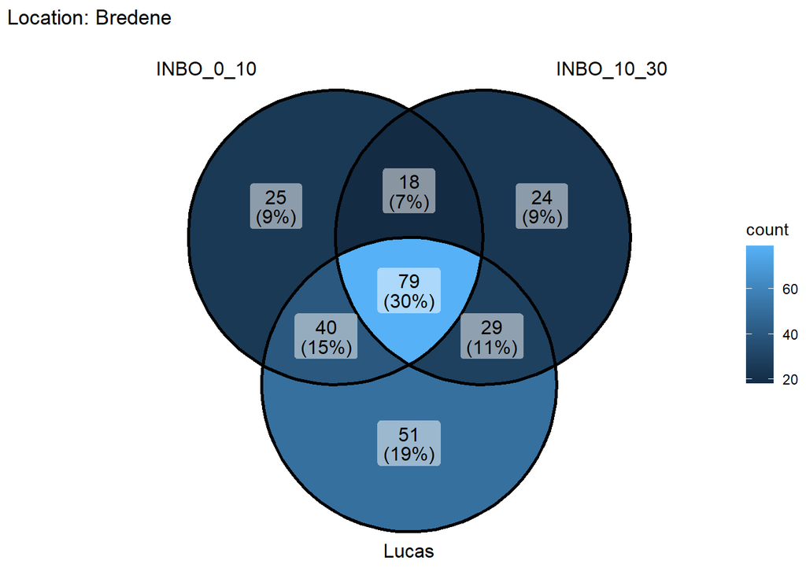

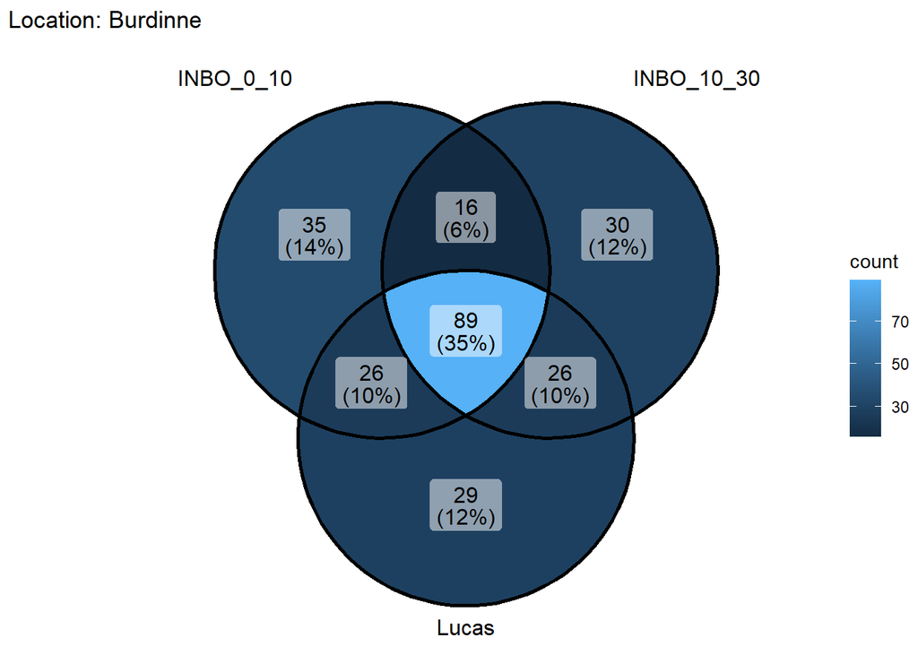

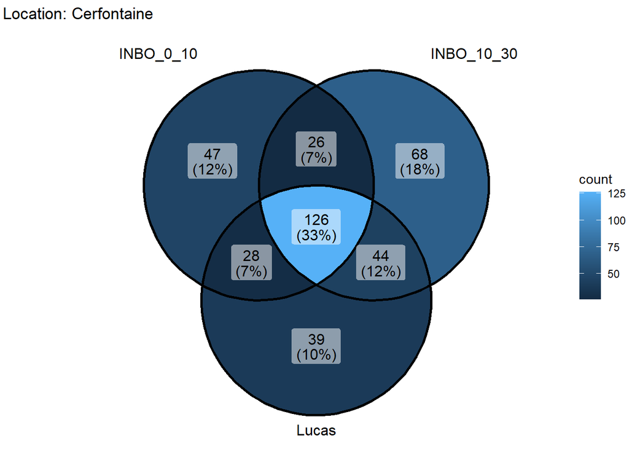

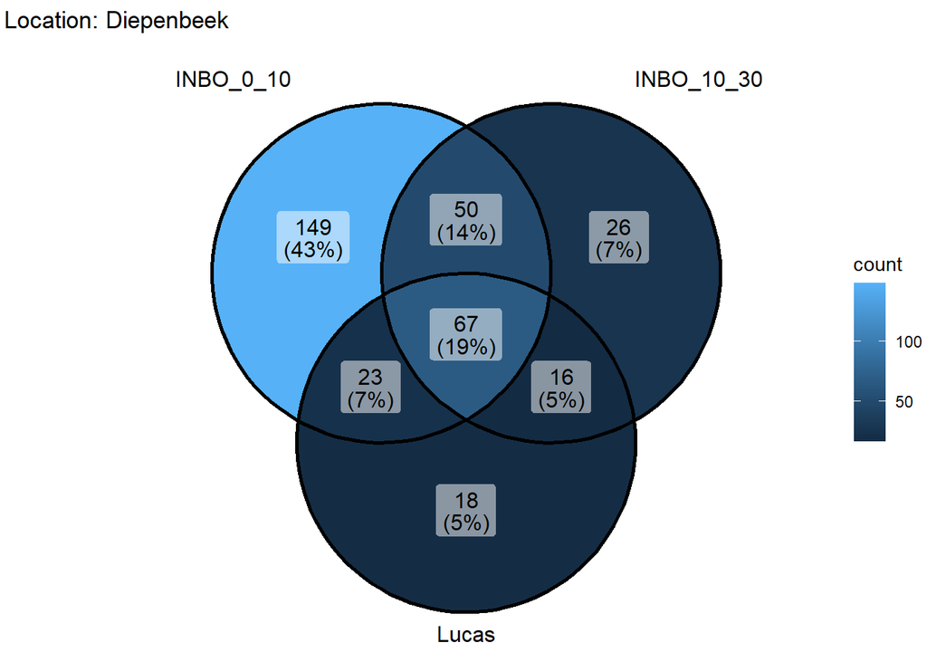

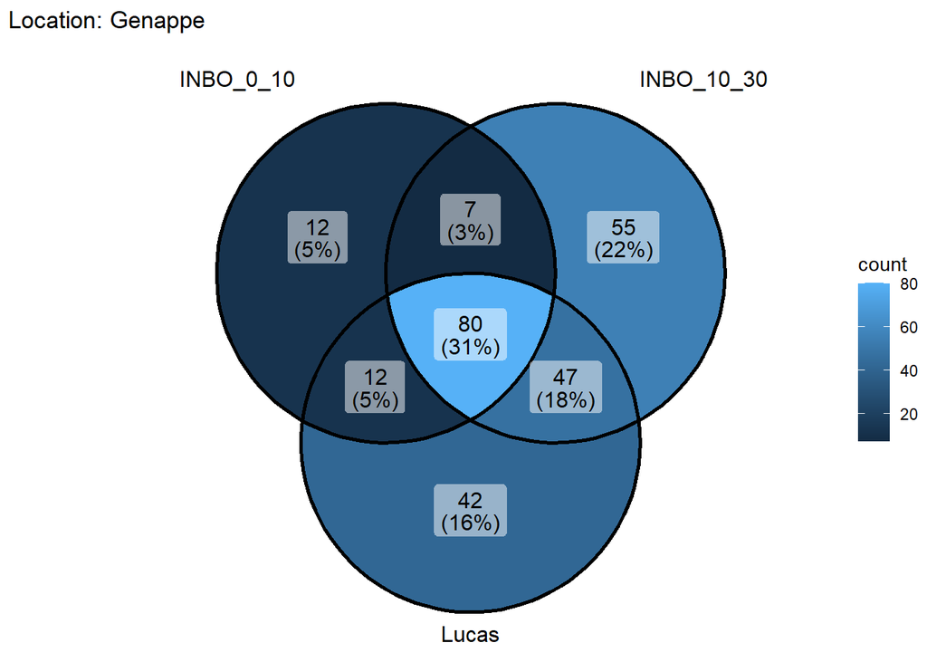

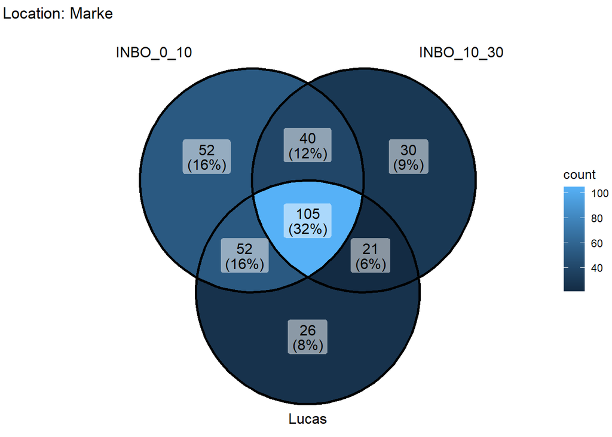

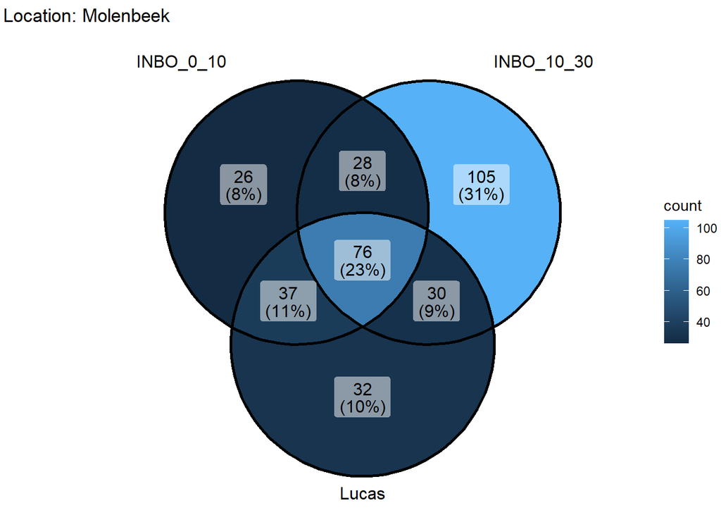

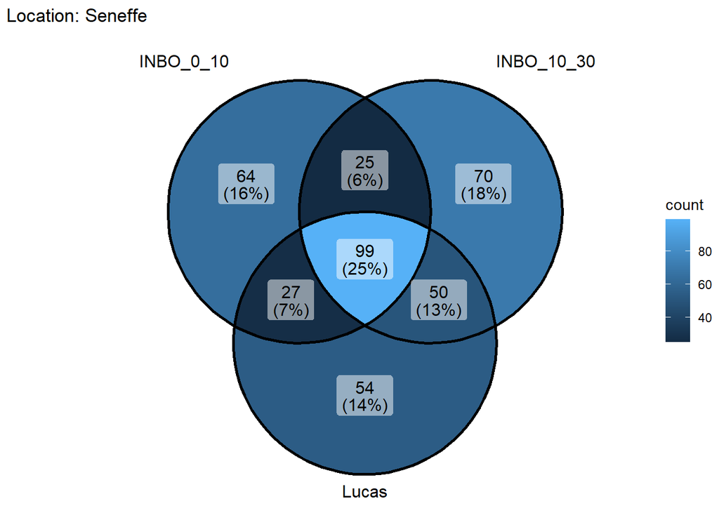

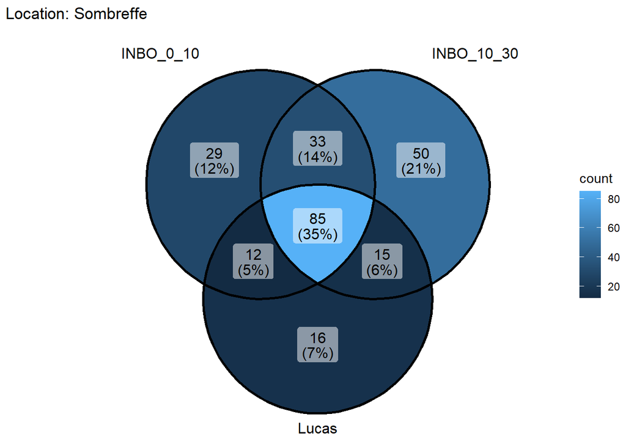

```r
# Remove samples
phyloseq_venn_filtered <- subset_samples_no_zero(phyloseq_venn, !(Name %in% samples_to_remove))
phyloseq_venn_filtered <- subset_samples_no_zero(phyloseq_venn_filtered, Layer != "litter")


# Make venn_diagram per
# Per locatie
phyloseq_venn_filtered_location <- phyloseq_venn_filtered

# List of unique locations
locations <- unique(sample_data(phyloseq_venn_filtered_location)$Location)

# Create an empty list to store the subsetted phyloseq objects
phyloseq_list <- list()

# Loop through each location
for (loc in locations) {
  # Subset the phyloseq object for the current location
  phyloseq_sub <- subset_samples_no_zero(phyloseq_venn_filtered_location, Location == loc)

  # Assign the subsetted phyloseq object to a variable with the location name
  assign(paste0("phyloseq_", loc), phyloseq_sub)

  # Store the subsetted phyloseq object in the list
  phyloseq_list[[loc]] <- phyloseq_sub
}


# List to store plots
plots_venn_locations <- list()


# Loop over each location
for (location in locations) {
  # Create tidy_physeq object
  tidy_physeq_venn <- tidytacos::from_phyloseq(get(paste0("phyloseq_", location)))

  # Generate plot with specified size and add title
  plot <- tidy_physeq_venn %>%
    tidytacos::tacoplot_venn(Protocol2) +
    ggtitle(paste("Location:", location)) +
    expand_limits(x = c(-8, 10), y = c(-5, 5))  # Adjust expansion here

  # Store plot in the list
  plots_venn_locations[[location]] <- plot
}
# Now you can access each plot from the list and display it
for (location in locations) {
  print(plots_venn_locations[[location]])
}
```

### 3.4.2 2. Gekende soorten

```r
# Subset only known species
physeq_srs_known_species
```

```
## phyloseq-class experiment-level object
## otu_table()   OTU Table:         [ 314 taxa and 31 samples ]
## sample_data() Sample Data:       [ 31 samples by 25 sample variables ]
## tax_table()   Taxonomy Table:    [ 314 taxa by 7 taxonomic ranks ]
```

```r
# Your original phyloseq object (replace with your actual object)
phyloseq_species_venn <- physeq_srs_known_species

print(phyloseq_species_venn)
```

```
## phyloseq-class experiment-level object
## otu_table()   OTU Table:         [ 314 taxa and 31 samples ]
## sample_data() Sample Data:       [ 31 samples by 25 sample variables ]
## tax_table()   Taxonomy Table:    [ 314 taxa by 7 taxonomic ranks ]
```

```r
# Extract sample data
sample_data <- as.data.frame(sample_data(phyloseq_species_venn))

# Extract unique locations and corresponding protocols
locations <- unique(sample_data$Location)
protocols <- lapply(locations, function(loc) unique(sample_data$Protocol[sample_data$Location == loc]))

# Initialize vector to store samples to be removed
samples_to_remove <- character(0)

# Identify samples to be removed based on conditions
for (i in seq_along(locations)) {
  if (length(protocols[[i]]) == 1 && protocols[[i]] == "INBO") {
    samples_to_remove <- c(samples_to_remove, rownames(sample_data[sample_data$Location == locations[i], ]))
  }
}

# Remove duplicates
samples_to_remove <- unique(samples_to_remove)

# Which samples need to be removed?
samples_to_remove
```

```
## [1] "Deurne_10_30"    "Herentals_0_10"  "Herentals_10_30"
```

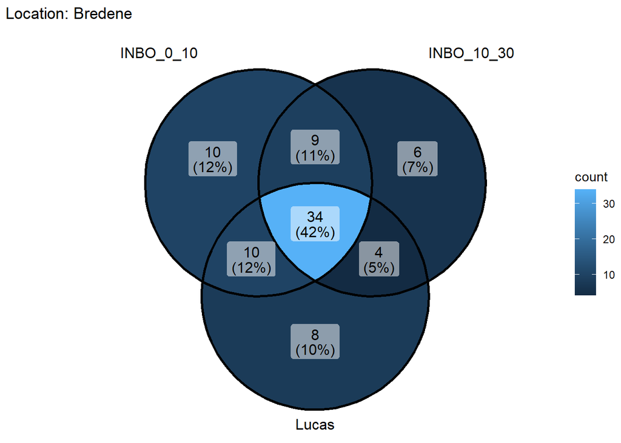

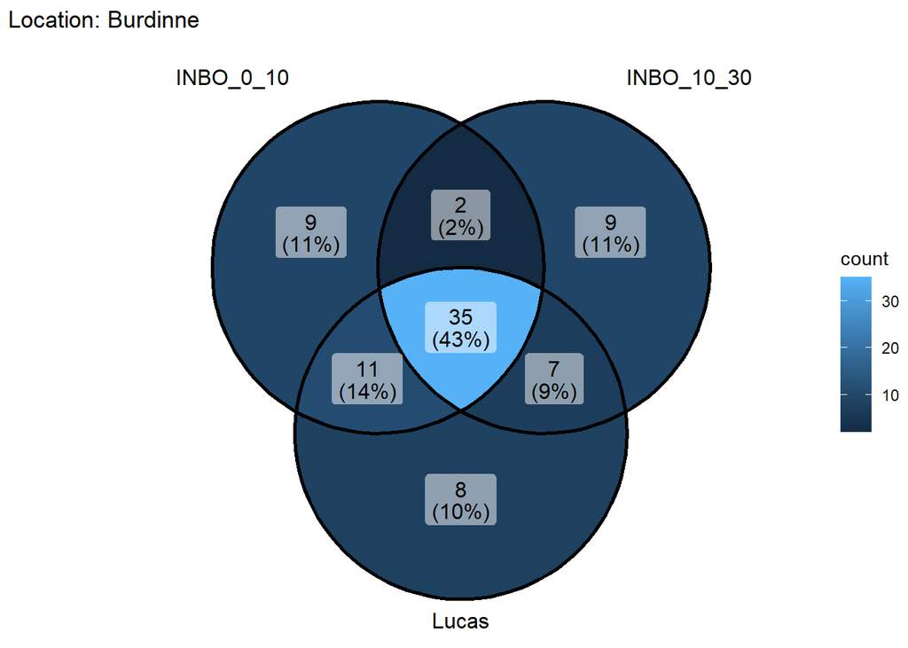

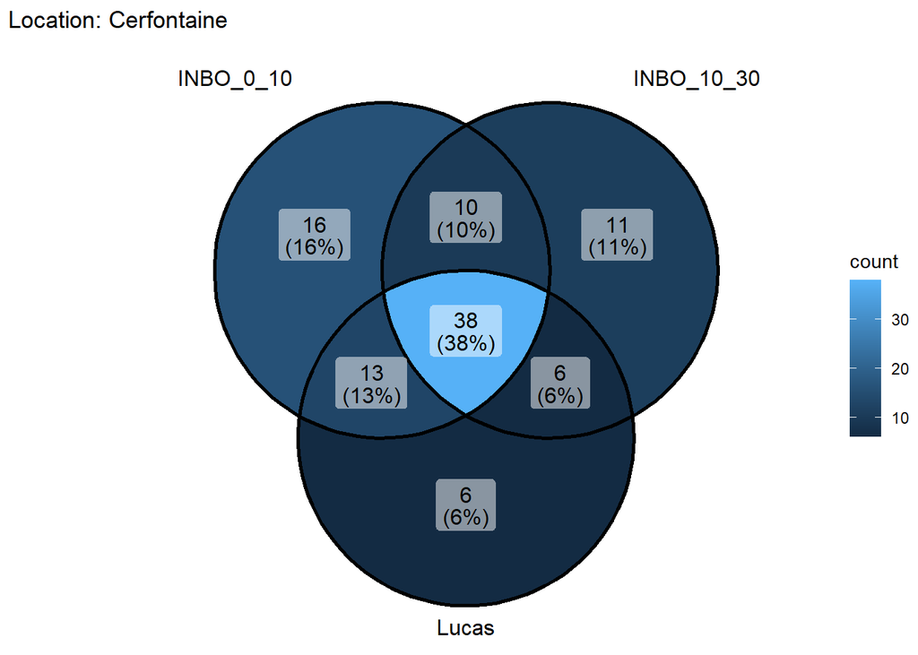

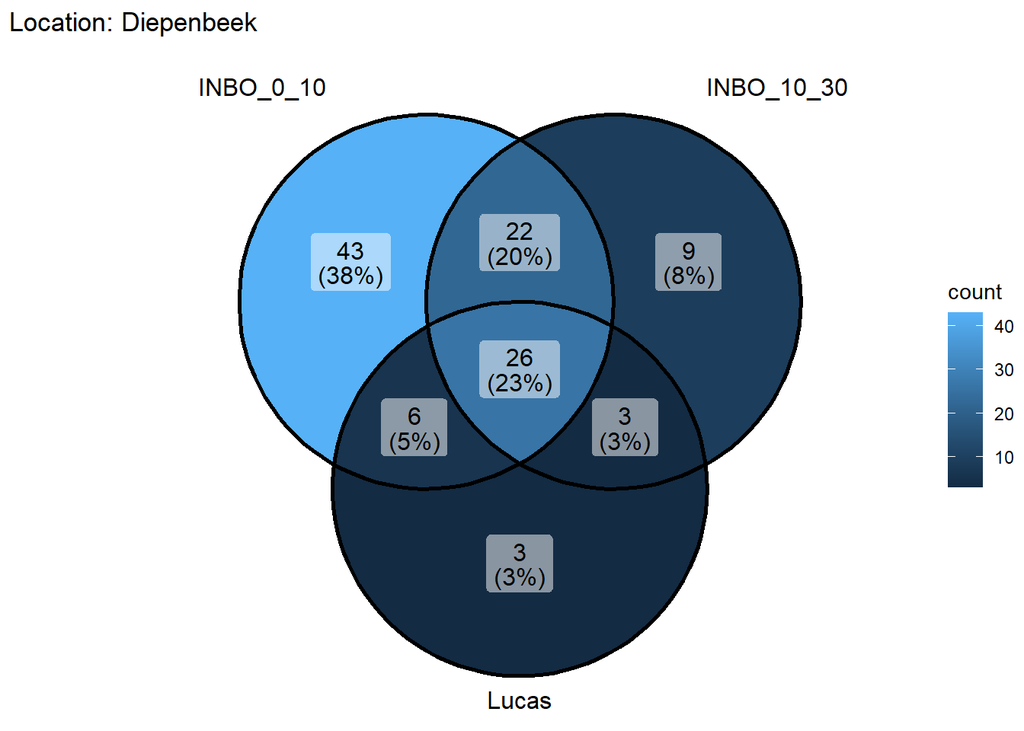

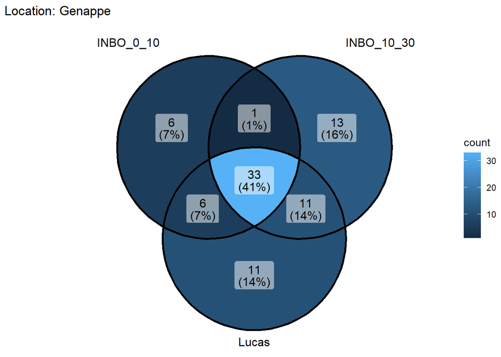

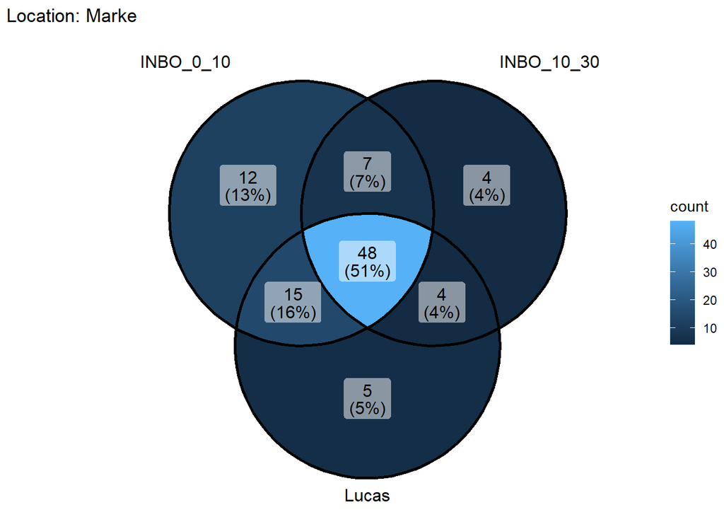

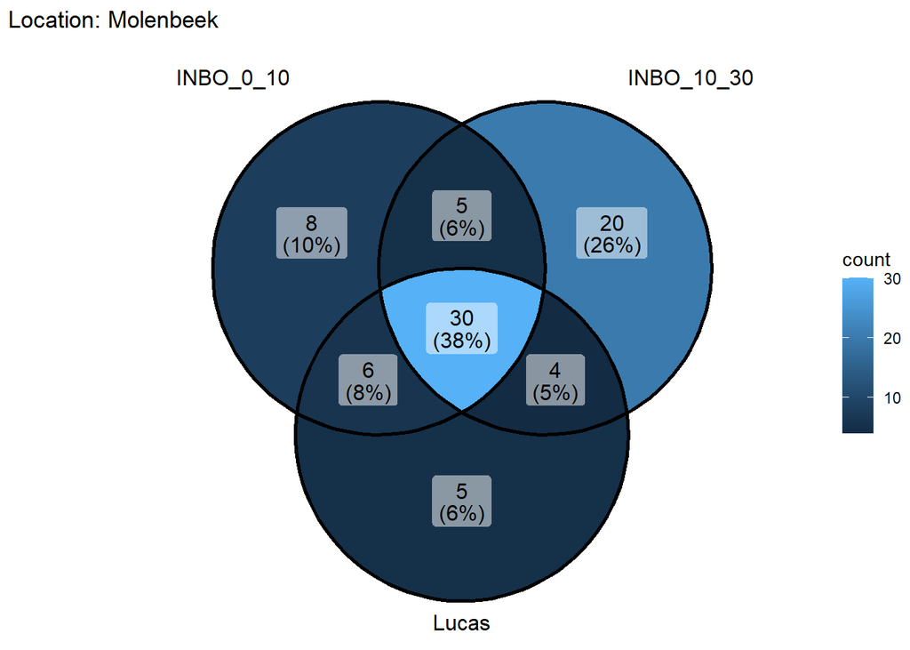

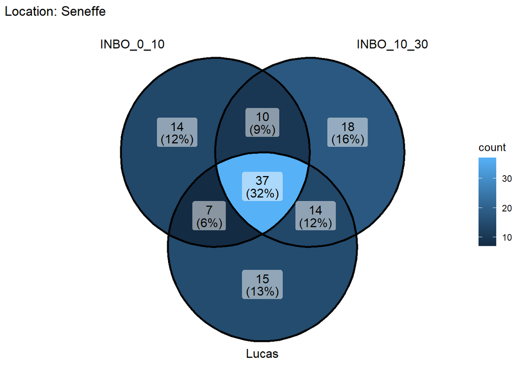

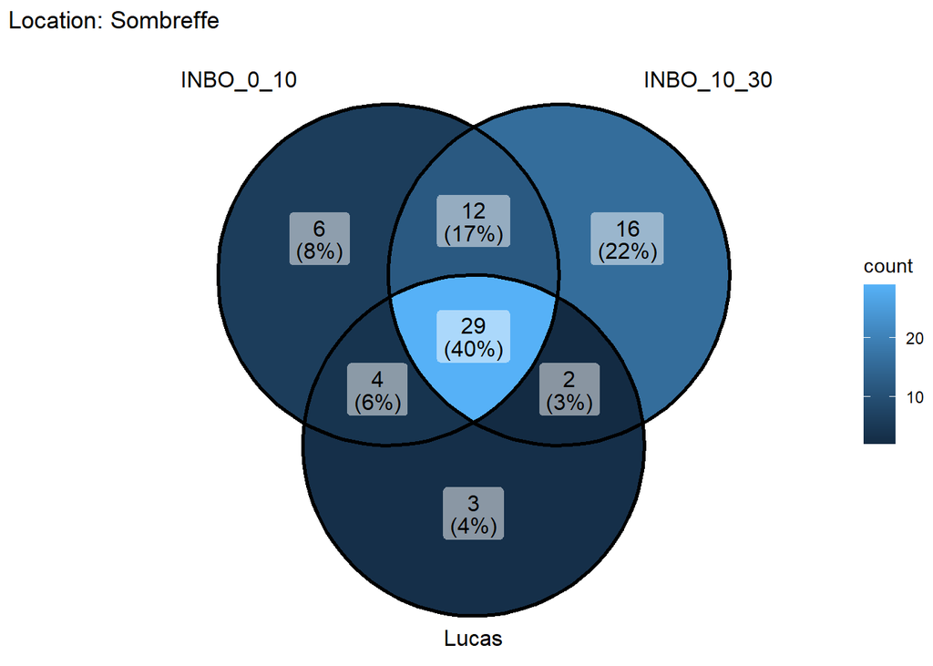

```r
# Remove samples
phyloseq_species_venn_filtered <- subset_samples_no_zero(phyloseq_species_venn, !(Name %in% samples_to_remove))
phyloseq_species_venn_filtered <- subset_samples_no_zero(phyloseq_species_venn_filtered, Layer != "litter")


# Make venn_diagram per
# Per locatie
phyloseq_species_venn__filtered_location <- phyloseq_species_venn_filtered

# List of unique locations
locations <- unique(sample_data(phyloseq_species_venn__filtered_location)$Location)

# Create an empty list to store the subsetted phyloseq objects
phyloseq_list <- list()

# Loop through each location
for (loc in locations) {
  # Subset the phyloseq object for the current location
  phyloseq_sub <- subset_samples_no_zero(phyloseq_species_venn__filtered_location, Location == loc)

  # Assign the subsetted phyloseq object to a variable with the location name
  assign(paste0("phyloseq_", loc), phyloseq_sub)

  # Store the subsetted phyloseq object in the list
  phyloseq_list[[loc]] <- phyloseq_sub
}


# List to store plots
plots_venn_locations <- list()


# Loop over each location
for (location in locations) {
  # Create tidy_physeq object
  tidy_physeq_venn <- tidytacos::from_phyloseq(get(paste0("phyloseq_", location)))

  # Generate plot with specified size and add title
  plot <- tidy_physeq_venn %>%
    tidytacos::tacoplot_venn(Protocol2) +
    ggtitle(paste("Location:", location)) +
    expand_limits(x = c(-8, 10), y = c(-5, 5))  # Adjust expansion here

  # Store plot in the list
  plots_venn_locations[[location]] <- plot
}
# Now you can access each plot from the list and display it
for (location in locations) {
  print(plots_venn_locations[[location]])
}
```

### 3.4.3 Gekende soorten al dan niet gemist met bepaalde staalname protocollen per locatie

#### 3.4.3.1 Species niveau

```r
# 1. Preprocessing for all comparisons

# Subset only known species
physeq_srs_known_species # KAN IK HIERMEE WERKEN???
```

```
## phyloseq-class experiment-level object
## otu_table()   OTU Table:         [ 314 taxa and 31 samples ]
## sample_data() Sample Data:       [ 31 samples by 25 sample variables ]
## tax_table()   Taxonomy Table:    [ 314 taxa by 7 taxonomic ranks ]
```

```r
otu_table <- otu_table(physeq_srs_known_species)
head(otu_table)
```

```
## OTU Table:          [6 taxa and 31 samples]
##                      taxa are rows
##         Bredene_0_10 Bredene_10_30 Bredene_Lucas Burdinne_0_10 Burdinne_10_30
## OTU10              1             0             0             2              0
## OTU1000            0             0             0             0              0
## OTU1006            1             1             5             0              0
## OTU1009            0             0             1             0              0
## OTU1019            0             0             0             0              0
## OTU1020            0             0             0             1              4
##         Burdinne_Lucas Cerfontaine_0_10 Cerfontaine_10_30 Cerfontaine_Lucas
## OTU10                4                2                 1                 0
## OTU1000              0               11                11                14
## OTU1006              0                0                17                18
## OTU1009              0                0                 1                 1
## OTU1019              0                5                 6                 5
## OTU1020              3                0                 1                 0
##         Deurne_10_30 Diepenbeek_0_10 Diepenbeek_10_30 Diepenbeek_Lucas
## OTU10              0               0                0                0
## OTU1000            1               1                2                0
## OTU1006           11               0                0                0
## OTU1009            0               0                0                0
## OTU1019            0               0                0                0
## OTU1020            0               0                0                0
##         Diepenbeek_strooisel Genappe_0_10 Genappe_10_30 Genappe_Lucas
## OTU10                      0            4            17             9
## OTU1000                    0            0             1             0
## OTU1006                    0            0             0             0
## OTU1009                    0            0             1             1
## OTU1019                    0            0             0             0
## OTU1020                    0            1             0             1
##         Herentals_0_10 Herentals_10_30 Marke_0_10 Marke_10_30 Marke_Lucas
## OTU10                0               0          0           0           0
## OTU1000              2               7          2           1           1
## OTU1006              0               2          0           0           0
## OTU1009              0               0          0           0           0
## OTU1019              0               0          0           0           0
## OTU1020              0               0          0           0           0
##         Molenbeek_0_10 Molenbeek_10_30 Molenbeek_Lucas Seneffe_0_10
## OTU10                0               0               0            1
## OTU1000              0               2               1            1
## OTU1006            333             106             170            0
## OTU1009              0               0               0            2
## OTU1019              0               0               0            0
## OTU1020              0               0               0            1
##         Seneffe_10_30_1 Seneffe_Lucas Sombreffe_0_10_1 Sombreffe_10_30
## OTU10                 2             2               27               8
## OTU1000               2             3                2               1
## OTU1006               0             0                0               0
## OTU1009               2             2                3               1
## OTU1019               0             0                0               0
## OTU1020               0             1                0               0
##         Sombreffe_Lucas
## OTU10                 4
## OTU1000               1
## OTU1006               0
## OTU1009               0
## OTU1019               0
## OTU1020               0
```

```r
tax_table <- tax_table(physeq_srs_known_species)
head(tax_table)
```

```
## Taxonomy Table:     [6 taxa by 7 taxonomic ranks]:
##         Domain  Phylum              Class                Order
## OTU10   "Fungi" "Ascomycota"        "Sordariomycetes"    "Sordariales"
## OTU1000 "Fungi" "Ascomycota"        "Sordariomycetes"    "Sordariales"
## OTU1006 "Fungi" "Ascomycota"        "Sordariomycetes"    "Hypocreales"
## OTU1009 "Fungi" "Ascomycota"        "Sordariomycetes"    "Sordariales"
## OTU1019 "Fungi" "Mortierellomycota" "Mortierellomycetes" "Mortierellales"
## OTU1020 "Fungi" "Ascomycota"        "Sordariomycetes"    "Hypocreales"
##         Family                           Genus
## OTU10   "Lasiosphaeriaceae"              "Cladorrhinum"
## OTU1000 "Chaetomiaceae"                  "Trichocladium"
## OTU1006 "Clavicipitaceae"                "Metarhizium"
## OTU1009 "Sordariales_fam_Incertae_sedis" "Remersonia"
## OTU1019 "Mortierellaceae"                "Mortierella"
## OTU1020 "Bionectriaceae"                 "Clonostachys"
##         Species
## OTU10   "Cladorrhinum_foecundissimum"
## OTU1000 "Trichocladium_opacum"
## OTU1006 "Metarhizium_anisopliae"
## OTU1009 "Remersonia_thermophila"
## OTU1019 "Mortierella_hypsicladia"
## OTU1020 "Clonostachys_divergens"
```

```r
sample_data <- sample_data(physeq_srs_known_species)
head(sample_data)
```

```
##                          Name Location DNA_extraction_method Protocol
## Bredene_0_10     Bredene_0_10  Bredene             Powersoil     INBO
## Bredene_10_30   Bredene_10_30  Bredene             Powersoil     INBO
## Bredene_Lucas   Bredene_Lucas  Bredene             Powersoil    Lucas
## Burdinne_0_10   Burdinne_0_10 Burdinne             Powersoil     INBO
## Burdinne_10_30 Burdinne_10_30 Burdinne             Powersoil     INBO
## Burdinne_Lucas Burdinne_Lucas Burdinne             Powersoil    Lucas
##                 Protocol2 Layer Ground_cover Land_use EUNIS Vegetation
## Bredene_0_10    INBO_0_10  0-10     Cropland Cropland    V1       Corn
## Bredene_10_30  INBO_10_30 10-30     Cropland Cropland    V1       Corn
## Bredene_Lucas       Lucas  0-20     Cropland Cropland    V1       Corn
## Burdinne_0_10   INBO_0_10  0-10     Cropland Cropland    V1     Potato
## Burdinne_10_30 INBO_10_30 10-30     Cropland Cropland    V1     Potato
## Burdinne_Lucas      Lucas  0-20     Cropland Cropland    V1     Potato
##                Vegetation2 Vegetation3 Vegetation4 Vegetation5 Processed
## Bredene_0_10          None        None        None        Mono        No
## Bredene_10_30         None        None        None        Mono        No
## Bredene_Lucas         None        None        None        Mono        No
## Burdinne_0_10         None        None        None        Mono        No
## Burdinne_10_30        None        None        None        Mono        No
## Burdinne_Lucas        None        None        None        Mono        No
##                Weather    Previous_weather Slope Soil_disturbance Ditches
## Bredene_0_10    Cloudy       Precipitation    No    Soil_wounding      No
## Bredene_10_30   Cloudy       Precipitation    No    Soil_wounding      No
## Bredene_Lucas   Cloudy       Precipitation    No    Soil_wounding      No
## Burdinne_0_10    Sunny Heavy_precipitation    No    Soil_wounding     Yes
## Burdinne_10_30   Sunny Heavy_precipitation    No    Soil_wounding     Yes
## Burdinne_Lucas   Sunny Heavy_precipitation    No    Soil_wounding     Yes
##                Harvest_residues Gravel Charcoal Rust Anthropogenic_material
## Bredene_0_10                Yes     No       No   No                     No
## Bredene_10_30               Yes     No       No   No                     No
## Bredene_Lucas               Yes     No       No   No                     No
## Burdinne_0_10               Yes     No       No   No                     No
## Burdinne_10_30              Yes     No       No   No                     No
## Burdinne_Lucas              Yes     No       No   No                     No
```

```r
unique(sample_data(physeq_srs_known_species)$Protocol2)
```

```
## [1] "INBO_0_10"  "INBO_10_30" "Lucas"      "strooisel"
```

```r
locations <- unique(sample_data(physeq_srs_known_species)$Location)

# Extract locations with both INBO and Lucas protocols
locations_with_lucas <- unique(sample_data(physeq_srs_known_species)$Location[sample_data(physeq_srs_known_species)$Protocol2 == "Lucas"])
```

##### 3.4.3.1.1 INBO_0_10 vs Lucas

```r
# INBO_0_10 vs Lucas

# Comparison of Detection Methods
for (loc in locations) {
  # Skip locations where Lucas protocol doesn't exist
  if (!(loc %in% locations_with_lucas)) {
    next
  }

  # Subset phyloseq object for the current location
  physeq_loc <- subset_samples(physeq_srs_known_species, Location == loc)


  # Subset OTU table for INBO_0_10 method
  otu_table_inbo <- otu_table(physeq_loc)[, sample_data(physeq_loc)$Protocol2 == "INBO_0_10"]

# Get OTU IDs detected using INBO_0_10 method
  otu_ids_inbo <- rownames(otu_table_inbo)[apply(otu_table_inbo, 1, function(x) sum(x) > 0)]

# Subset OTU table for LUCAS method
  otu_table_lucas <- otu_table(physeq_loc)[, sample_data(physeq_loc)$Protocol2 == "Lucas"]

# Get OTU IDs detected using LUCAS method
  otu_ids_lucas <- rownames(otu_table_lucas)[apply(otu_table_lucas, 1, function(x) sum(x) > 0)]


  # Get species names corresponding to OTU IDs detected using INBO_0_10 method
  species_names_inbo <- tax_table(physeq_loc)[otu_ids_inbo, "Species"]

  # Check if there are OTU IDs detected using INBO_0_10 method
  if (length(otu_ids_inbo) == 0) {
  # If no OTU IDs detected using INBO_0_10 method, assign a placeholder value
  species_names_inbo <- character(0)  # Or any appropriate placeholder
  }

  # Check if there are OTU IDs detected using LUCAS method
  if (length(otu_ids_lucas) == 0) {
  # If no OTU IDs detected using LUCAS method, assign a placeholder value
  species_names_lucas <- character(0)  # Or any appropriate placeholder
  } else {
  # Get species names corresponding to OTU IDs detected using LUCAS method
  species_names_lucas <- tax_table(physeq_loc)[otu_ids_lucas, "Species"]
  }

# Find species detected with INBO_0_10 but not LUCAS
  species_inbo_not_lucas <- setdiff(species_names_inbo, species_names_lucas)


  if (length(species_inbo_not_lucas) == 0) {
    cat("Location:", loc, "\n")
    cat("No species detected using INBO_0_10 that are not detected using LUCAS.\n\n")
  } else {
    cat("Location:", loc, "\n")
    cat("Species detected using INBO_0_10 but not LUCAS:", paste(species_inbo_not_lucas, collapse = ", "), "\n\n")
  }
}
```

```
## Location: Bredene
## Species detected using INBO_0_10 but not LUCAS: Cladorrhinum_foecundissimum, Gibberella_intricans, Mucor_hiemalis, Ustilago_maydis, Sporobolomyces_roseus, Penicillium_neocrassum, Cladorrhinum_phialophoroides, Cystofilobasidium_macerans, Fusarium_venenatum, Gibberella_zeae, Penicillium_scabrosum, …
##
## Location: Burdinne
## Species detected using INBO_0_10 but not LUCAS: Metarhizium_marquandii, Mucor_circinelloides, Filobasidium_chernovii, Trichoderma_viride, Annulohypoxylon_multiforme, Gymnoascus_reessii, Coprinellus_micaceus, Dichotomopilus_erectus, Pyrenochaetopsis_leptospora, Scedosporium_dehoogii, Holtermanniel…
##
## Location: Cerfontaine
## Species detected using INBO_0_10 but not LUCAS: Cladorrhinum_foecundissimum, Gibberella_intricans, Mucor_hiemalis, Stachybotrys_chartarum, Mortierella_amoeboidea, Auxarthron_umbrinum, Arthrographis_longispora, Ustilago_maydis, Mortierella_gamsii, Byssonectria_fusispora, Metarhizium_flavoviride, M…
##
## Location: Diepenbeek
## Species detected using INBO_0_10 but not LUCAS: Trichocladium_opacum, Apiotrichum_gracile, Solicoccozyma_terrea, Umbelopsis_vinacea, Aureobasidium_pullulans, Mycosphaerella_tassiana, Penicillium_catenatum, Mariannaea_pinicola, Botryobasidium_subcoronatum, Cortinarius_saniosus, Arthrographis_longi…
##
## Location: Genappe
## Species detected using INBO_0_10 but not LUCAS: Filobasidium_chernovii, Mycosphaerella_tassiana, Mycothermus_thermophilus, Powellomyces_hirtus, Ochroconis_tshawytschae, Alternaria_metachromatica, Holtermanniella_takashimae
##
## Location: Marke
## Species detected using INBO_0_10 but not LUCAS: Tuber_rapaeodorum, Penicillium_catenatum, Inocybe_squamata, Ganoderma_adspersum, Penicillium_christenseniae, Laccaria_bicolor, Apiotrichum_laibachii, Chaetosphaeria_myriocarpa, Preussia_flanaganii, Coprinellus_micaceus, Cadophora_finlandica, Stropha…
##
## Location: Molenbeek
## Species detected using INBO_0_10 but not LUCAS: Metarhizium_marquandii, Mariannaea_pinicola, Mycoarthris_corallina, Otidea_apophysata, Mortierella_alpina, Phallus_impudicus, Fusarium_venenatum, Fusarium_proliferatum, Acremonium_fusidioides, Tetragoniomyces_uliginosus, Coprinellus_verrucispermus, …
##
## Location: Seneffe
## Species detected using INBO_0_10 but not LUCAS: Aureobasidium_pullulans, Mycosphaerella_tassiana, Westerdykella_dispersa, Pyrenophora_lolii, Alternaria_breviramosa, Coprinellus_disseminatus, Agaricus_comtulus, Sarocladium_strictum, Fusarium_venenatum, Apodus_deciduus, Minimedusa_polyspora, Acremo…
##
## Location: Sombreffe
## Species detected using INBO_0_10 but not LUCAS: Remersonia_thermophila, Penicillium_polonicum, Solicoccozyma_terrea, Sporobolomyces_roseus, Chrysosporium_pseudomerdarium, Eucasphaeria_capensis, Dichotomopilus_pratensis, Cistella_albidolutea, Fusarium_venenatum, Hypholoma_fasciculare, Rhizophlycti…
```

##### 3.4.3.1.2 INBO (INBO_0_10 + INBO_10_30) vs Lucas

```r
### INBO (INBO_0_10 + INBO_10_30) vs Lucas

# Comparison of Detection Methods
for (loc in locations) {
  # Skip locations where Lucas protocol doesn't exist
  if (!(loc %in% locations_with_lucas)) {
    next
  }

  # Subset phyloseq object for the current location
  physeq_loc <- subset_samples(physeq_srs_known_species, Location == loc)


  # Subset OTU table for INBO method
  otu_table_inbo <- otu_table(physeq_loc)[, sample_data(physeq_loc)$Protocol == "INBO"]

# Get OTU IDs detected using INBO method
  otu_ids_inbo <- rownames(otu_table_inbo)[apply(otu_table_inbo, 1, function(x) sum(x) > 0)]

# Subset OTU table for LUCAS method
  otu_table_lucas <- otu_table(physeq_loc)[, sample_data(physeq_loc)$Protocol == "Lucas"]

# Get OTU IDs detected using LUCAS method
  otu_ids_lucas <- rownames(otu_table_lucas)[apply(otu_table_lucas, 1, function(x) sum(x) > 0)]


  # Get species names corresponding to OTU IDs detected using INBO method
  species_names_inbo <- tax_table(physeq_loc)[otu_ids_inbo, "Species"]

  # Check if there are OTU IDs detected using INBO method
  if (length(otu_ids_inbo) == 0) {
  # If no OTU IDs detected using INBO method, assign a placeholder value
  species_names_inbo <- character(0)  # Or any appropriate placeholder
  }

  # Check if there are OTU IDs detected using LUCAS method
  if (length(otu_ids_lucas) == 0) {
  # If no OTU IDs detected using LUCAS method, assign a placeholder value
  species_names_lucas <- character(0)  # Or any appropriate placeholder
  } else {
  # Get species names corresponding to OTU IDs detected using LUCAS method
  species_names_lucas <- tax_table(physeq_loc)[otu_ids_lucas, "Species"]
  }

  # Find species detected with INBO but not LUCAS
  species_inbo_not_lucas <- setdiff(species_names_inbo, species_names_lucas)


  if (length(species_inbo_not_lucas) == 0) {
    cat("Location:", loc, "\n")
    cat("No species detected using INBO that are not detected using LUCAS.\n\n")
  } else {
    cat("Location:", loc, "\n")
    cat("Species detected using INBO but not LUCAS:", paste(species_inbo_not_lucas, collapse = ", "), "\n\n")
  }
}
```

```
## Location: Bredene
## Species detected using INBO but not LUCAS: Cladorrhinum_foecundissimum, Gibberella_intricans, Mucor_hiemalis, Gibellulopsis_piscis, Mucor_laxorrhizus, Arthrographis_longispora, Ustilago_maydis, Sporobolomyces_roseus, Penicillium_neocrassum, Cladorrhinum_phialophoroides, Cystofilobasidium_macerans…
##
## Location: Burdinne
## Species detected using INBO but not LUCAS: Metarhizium_marquandii, Mucor_circinelloides, Filobasidium_chernovii, Trichoderma_viride, Mycothermus_thermophilus, Sporobolomyces_roseus, Entoloma_sericeum, Annulohypoxylon_multiforme, Scytalidium_lignicola, Gymnoascus_reessii, Coprinellus_micaceus, Min…
##
## Location: Cerfontaine
## Species detected using INBO but not LUCAS: Cladorrhinum_foecundissimum, Clonostachys_divergens, Gibberella_intricans, Solicoccozyma_terrea, Mucor_hiemalis, Stachybotrys_chartarum, Mortierella_amoeboidea, Auxarthron_umbrinum, Arthrographis_longispora, Ustilago_maydis, Mortierella_gamsii, Podospora…
##
## Location: Diepenbeek
## Species detected using INBO but not LUCAS: Trichocladium_opacum, Apiotrichum_gracile, Mucor_circinelloides, Solicoccozyma_terrea, Umbelopsis_vinacea, Aureobasidium_pullulans, Mycosphaerella_tassiana, Cunninghamella_elegans, Penicillium_catenatum, Mariannaea_pinicola, Botryobasidium_subcoronatum, …
##
## Location: Genappe
## Species detected using INBO but not LUCAS: Trichocladium_opacum, Penicillium_polonicum, Filobasidium_chernovii, Mycosphaerella_tassiana, Mycothermus_thermophilus, Arthrographis_longispora, Powellomyces_hirtus, Ochroconis_tshawytschae, Preussia_flanaganii, Fusarium_proliferatum, Minimedusa_polyspo…
##
## Location: Marke
## Species detected using INBO but not LUCAS: Tuber_rapaeodorum, Penicillium_catenatum, Umbelopsis_ramanniana, Penicillium_zhuangii, Inocybe_squamata, Ganoderma_adspersum, Penicillium_christenseniae, Laccaria_bicolor, Apiotrichum_laibachii, Chaetosphaeria_myriocarpa, Preussia_flanaganii, Coprinellus…
##
## Location: Molenbeek
## Species detected using INBO but not LUCAS: Metarhizium_marquandii, Solicoccozyma_terrea, Mycosphaerella_tassiana, Mariannaea_pinicola, Auxarthron_umbrinum, Inocybe_curvipes, Mycoarthris_corallina, Byssonectria_fusispora, Chrysosporium_pseudomerdarium, Otidea_apophysata, Coprinellus_disseminatus, …
##
## Location: Seneffe
## Species detected using INBO but not LUCAS: Metarhizium_marquandii, Aureobasidium_pullulans, Mycosphaerella_tassiana, Mucor_hiemalis, Mortierella_amoeboidea, Arthrographis_longispora, Mortierella_gamsii, Westerdykella_dispersa, Pyrenophora_lolii, Entoloma_sericeum, Alternaria_breviramosa, Coprinel…
##
## Location: Sombreffe
## Species detected using INBO but not LUCAS: Remersonia_thermophila, Penicillium_polonicum, Gibberella_intricans, Solicoccozyma_terrea, Colletotrichum_coccodes, Mortierella_amoeboidea, Microdochium_trichocladiopsis, Acremonium_nepalense, Sporobolomyces_roseus, Barnettozyma_californica, Chrysosporiu…
```

##### 3.4.3.1.3 Lucas vs INBO_0_10

```r
# Lucas vs INBO_0_10

# Comparison of Detection Methods
for (loc in locations) {
  # Skip locations where Lucas protocol doesn't exist
  if (!(loc %in% locations_with_lucas)) {
    next
  }

  # Subset phyloseq object for the current location
  physeq_loc <- subset_samples(physeq_srs_known_species, Location == loc)


  # Subset OTU table for INBO_0_10 method
  otu_table_inbo <- otu_table(physeq_loc)[, sample_data(physeq_loc)$Protocol2 == "INBO_0_10"]

# Get OTU IDs detected using INBO_0_10 method
  otu_ids_inbo <- rownames(otu_table_inbo)[apply(otu_table_inbo, 1, function(x) sum(x) > 0)]

# Subset OTU table for LUCAS method
  otu_table_lucas <- otu_table(physeq_loc)[, sample_data(physeq_loc)$Protocol2 == "Lucas"]

# Get OTU IDs detected using LUCAS method
  otu_ids_lucas <- rownames(otu_table_lucas)[apply(otu_table_lucas, 1, function(x) sum(x) > 0)]


  # Get species names corresponding to OTU IDs detected using INBO_0_10 method
  species_names_inbo <- tax_table(physeq_loc)[otu_ids_inbo, "Species"]

  # Check if there are OTU IDs detected using INBO_0_10 method
  if (length(otu_ids_inbo) == 0) {
  # If no OTU IDs detected using INBO_0_10 method, assign a placeholder value
  species_names_inbo <- character(0)  # Or any appropriate placeholder
  }

  # Check if there are OTU IDs detected using LUCAS method
  if (length(otu_ids_lucas) == 0) {
  # If no OTU IDs detected using LUCAS method, assign a placeholder value
  species_names_lucas <- character(0)  # Or any appropriate placeholder
  } else {
  # Get species names corresponding to OTU IDs detected using LUCAS method
  species_names_lucas <- tax_table(physeq_loc)[otu_ids_lucas, "Species"]
  }

# Find species detected with LUCAS but not INBO_0_10
  species_lucas_not_inbo <- setdiff(species_names_lucas, species_names_inbo)


  if (length(species_lucas_not_inbo) == 0) {
    cat("Location:", loc, "\n")
    cat("No species detected using LUCAS that are not detected using INBO_0_10.\n\n")
  } else {
    cat("Location:", loc, "\n")
    cat("Species detected using LUCAS but not INBO_0_10:", paste(species_lucas_not_inbo, collapse = ", "), "\n\n")
  }
}
```

```
## Location: Bredene
## Species detected using LUCAS but not INBO_0_10: Remersonia_thermophila, Metarhizium_marquandii, Filobasidium_chernovii, Fusarium_solani, Gongronella_butleri, Agaricus_comtulus, Ilyonectria_mors-panacis, Pseudogymnoascus_roseus, Ilyonectria_macrodidyma, Metacordyceps_chlamydosporia, Conocybe_velut…
##
## Location: Burdinne
## Species detected using LUCAS but not INBO_0_10: Apiotrichum_gracile, Fusarium_solani, Eucasphaeria_capensis, Solicoccozyma_terricola, Trichoderma_compactum, Torula_herbarum, Vishniacozyma_carnescens, Vishniacozyma_heimaeyensis, Ilyonectria_mors-panacis, Tetragoniomyces_uliginosus, Phialocephala_h…
##
## Location: Cerfontaine
## Species detected using LUCAS but not INBO_0_10: Metarhizium_anisopliae, Remersonia_thermophila, Gibellulopsis_piscis, Absidia_glauca, Amauroascus_albicans, Coprinellus_micaceus, Minimedusa_polyspora, Periconia_cookei, Geotrichum_europaeum, Lecanicillium_subprimulinum, Slooffia_cresolica, Byssonec…
##
## Location: Diepenbeek
## Species detected using LUCAS but not INBO_0_10: Mortierella_amoeboidea, Ganoderma_adspersum, Entoloma_sericeum, Amanita_muscaria, Cadophora_finlandica, Penicillium_bissettii
##
## Location: Genappe
## Species detected using LUCAS but not INBO_0_10: Remersonia_thermophila, Colletotrichum_coccodes, Stachybotrys_chartarum, Sporobolomyces_roseus, Fusarium_solani, Botryotrichum_atrogriseum, Barnettozyma_californica, Byssonectria_fusispora, Chrysosporium_pseudomerdarium, Operculomyces_laminatus, Par…
##
## Location: Marke
## Species detected using LUCAS but not INBO_0_10: Cortinarius_saniosus, Coprinellus_disseminatus, Inocybe_perlata, Penicillium_glabrum, Penicillium_virgatum, Vishniacozyma_carnescens, Mycena_albidoaquosa, Ilyonectria_macrodidyma, Mortierella_indohii
##
## Location: Molenbeek
## Species detected using LUCAS but not INBO_0_10: Trichocladium_opacum, Mucor_minutus, Cunninghamella_elegans, Mucor_hiemalis, Slopeiomyces_cylindrosporus, Mortierella_humilis, Sagenomella_oligospora, Aspergillus_collinsii, Conocybe_velutipes
##
## Location: Seneffe
## Species detected using LUCAS but not INBO_0_10: Westerdykella_nigra, Mortierella_fatshederae, Stephanonectria_keithii, Trichoderma_viride, Mycothermus_thermophilus, Microdochium_trichocladiopsis, Sarocladium_kiliense, Fusarium_solani, Ganoderma_adspersum, Barnettozyma_californica, Acremonium_curv…
##
## Location: Sombreffe
## Species detected using LUCAS but not INBO_0_10: Trichoderma_viride, Trichophyton_ajelloi, Apodus_deciduus, Verticillium_nubilum, Trichoderma_lixii
```

##### 3.4.3.1.4 Lucas vs INBO (INBO_0_10 + INBO_10_30)

```r
# Lucas vs INBO (INBO_0_10 + INBO_10_30)

# Comparison of Detection Methods
for (loc in locations) {
  # Skip locations where Lucas protocol doesn't exist
  if (!(loc %in% locations_with_lucas)) {
    next
  }

  # Subset phyloseq object for the current location
  physeq_loc <- subset_samples(physeq_srs_known_species, Location == loc)


  # Subset OTU table for INBO method
  otu_table_inbo <- otu_table(physeq_loc)[, sample_data(physeq_loc)$Protocol == "INBO"]

# Get OTU IDs detected using INBO method
  otu_ids_inbo <- rownames(otu_table_inbo)[apply(otu_table_inbo, 1, function(x) sum(x) > 0)]

# Subset OTU table for LUCAS method
  otu_table_lucas <- otu_table(physeq_loc)[, sample_data(physeq_loc)$Protocol == "Lucas"]

# Get OTU IDs detected using LUCAS method
  otu_ids_lucas <- rownames(otu_table_lucas)[apply(otu_table_lucas, 1, function(x) sum(x) > 0)]


  # Get species names corresponding to OTU IDs detected using INBO method
  species_names_inbo <- tax_table(physeq_loc)[otu_ids_inbo, "Species"]

  # Check if there are OTU IDs detected using INBO_0_10 method
  if (length(otu_ids_inbo) == 0) {
  # If no OTU IDs detected using INBO method, assign a placeholder value
  species_names_inbo <- character(0)  # Or any appropriate placeholder
  }

  # Check if there are OTU IDs detected using LUCAS method
  if (length(otu_ids_lucas) == 0) {
  # If no OTU IDs detected using LUCAS method, assign a placeholder value
  species_names_lucas <- character(0)  # Or any appropriate placeholder
  } else {
  # Get species names corresponding to OTU IDs detected using LUCAS method
  species_names_lucas <- tax_table(physeq_loc)[otu_ids_lucas, "Species"]
  }

  # Find species detected with LUCAS but not INBO
  species_lucas_not_inbo <- setdiff(species_names_lucas, species_names_inbo)


  if (length(species_lucas_not_inbo) == 0) {
    cat("Location:", loc, "\n")
    cat("No species detected using LUCAS that are not detected using INBO.\n\n")
  } else {
    cat("Location:", loc, "\n")
    cat("Species detected using LUCAS but not INBO:", paste(species_lucas_not_inbo, collapse = ", "), "\n\n")
  }
}
```

```
## Location: Bredene
## Species detected using LUCAS but not INBO: Remersonia_thermophila, Metarhizium_marquandii, Filobasidium_chernovii, Fusarium_solani, Pseudogymnoascus_roseus, Metacordyceps_chlamydosporia, Conocybe_velutipes, Aspergillus_fumigatus
##
## Location: Burdinne
## Species detected using LUCAS but not INBO: Solicoccozyma_terricola, Trichoderma_compactum, Torula_herbarum, Vishniacozyma_carnescens, Vishniacozyma_heimaeyensis, Tetragoniomyces_uliginosus, Mortierella_indohii, Leucosporidium_drummii
##
## Location: Cerfontaine
## Species detected using LUCAS but not INBO: Coprinellus_micaceus, Periconia_cookei, Geotrichum_europaeum, Lecanicillium_subprimulinum, Slooffia_cresolica, Byssonectria_deformis
##
## Location: Diepenbeek
## Species detected using LUCAS but not INBO: Ganoderma_adspersum, Entoloma_sericeum, Amanita_muscaria
##
## Location: Genappe
## Species detected using LUCAS but not INBO: Colletotrichum_coccodes, Stachybotrys_chartarum, Sporobolomyces_roseus, Barnettozyma_californica, Byssonectria_fusispora, Acremonium_fusidioides, Rhizophlyctis_rosea, Talaromyces_purpureogenus, Acaulium_acremonium, Wardomyces_giganteus, Leucosporidium_dr…
##
## Location: Marke
## Species detected using LUCAS but not INBO: Coprinellus_disseminatus, Penicillium_glabrum, Penicillium_virgatum, Vishniacozyma_carnescens, Mycena_albidoaquosa
##
## Location: Molenbeek
## Species detected using LUCAS but not INBO: Mucor_minutus, Mucor_hiemalis, Slopeiomyces_cylindrosporus, Aspergillus_collinsii, Conocybe_velutipes
##
## Location: Seneffe
## Species detected using LUCAS but not INBO: Mortierella_fatshederae, Stephanonectria_keithii, Ganoderma_adspersum, Acremonium_curvulum, Gibberella_tricincta, Hypholoma_fasciculare, Aspergillus_collinsii, Periconia_cookei, Gamsia_simplex, Dictyosporium_elegans, Phialocephala_humicola, Mortierella_i…
##
## Location: Sombreffe
## Species detected using LUCAS but not INBO: Trichophyton_ajelloi, Apodus_deciduus, Trichoderma_lixii
```

#### 3.4.3.2 Genus niveau

```r
# 1. Preprocessing for all comparisons

# Subset only known genus
physeq_srs_known_genera <- subset_taxa(physeq_srs, !grepl("_otu", tax_table(physeq_srs)[, "Genus"]))

otu_table <- otu_table(physeq_srs_known_genera)
head(otu_table)
```

```
## OTU Table:          [6 taxa and 31 samples]
##                      taxa are rows
##         Bredene_0_10 Bredene_10_30 Bredene_Lucas Burdinne_0_10 Burdinne_10_30
## OTU10              1             0             0             2              0
## OTU1000            0             0             0             0              0
## OTU1006            1             1             5             0              0
## OTU1009            0             0             1             0              0
## OTU1017            0             0             0             0              0
## OTU1019            0             0             0             0              0
##         Burdinne_Lucas Cerfontaine_0_10 Cerfontaine_10_30 Cerfontaine_Lucas
## OTU10                4                2                 1                 0
## OTU1000              0               11                11                14
## OTU1006              0                0                17                18
## OTU1009              0                0                 1                 1
## OTU1017              0                0                 0                 0
## OTU1019              0                5                 6                 5
##         Deurne_10_30 Diepenbeek_0_10 Diepenbeek_10_30 Diepenbeek_Lucas
## OTU10              0               0                0                0
## OTU1000            1               1                2                0
## OTU1006           11               0                0                0
## OTU1009            0               0                0                0
## OTU1017            0               0                0                0
## OTU1019            0               0                0                0
##         Diepenbeek_strooisel Genappe_0_10 Genappe_10_30 Genappe_Lucas
## OTU10                      0            4            17             9
## OTU1000                    0            0             1             0
## OTU1006                    0            0             0             0
## OTU1009                    0            0             1             1
## OTU1017                    3            0             0             0
## OTU1019                    0            0             0             0
##         Herentals_0_10 Herentals_10_30 Marke_0_10 Marke_10_30 Marke_Lucas
## OTU10                0               0          0           0           0
## OTU1000              2               7          2           1           1
## OTU1006              0               2          0           0           0
## OTU1009              0               0          0           0           0
## OTU1017              0               0          0           0           0
## OTU1019              0               0          0           0           0
##         Molenbeek_0_10 Molenbeek_10_30 Molenbeek_Lucas Seneffe_0_10
## OTU10                0               0               0            1
## OTU1000              0               2               1            1
## OTU1006            333             106             170            0
## OTU1009              0               0               0            2
## OTU1017              0               0               0            0
## OTU1019              0               0               0            0
##         Seneffe_10_30_1 Seneffe_Lucas Sombreffe_0_10_1 Sombreffe_10_30
## OTU10                 2             2               27               8
## OTU1000               2             3                2               1
## OTU1006               0             0                0               0
## OTU1009               2             2                3               1
## OTU1017               0             0                0               0
## OTU1019               0             0                0               0
##         Sombreffe_Lucas
## OTU10                 4
## OTU1000               1
## OTU1006               0
## OTU1009               0
## OTU1017               0
## OTU1019               0
```

```r
tax_table <- tax_table(physeq_srs_known_genera)
head(tax_table)
```

```
## Taxonomy Table:     [6 taxa by 7 taxonomic ranks]:
##         Domain  Phylum              Class                Order
## OTU10   "Fungi" "Ascomycota"        "Sordariomycetes"    "Sordariales"
## OTU1000 "Fungi" "Ascomycota"        "Sordariomycetes"    "Sordariales"
## OTU1006 "Fungi" "Ascomycota"        "Sordariomycetes"    "Hypocreales"
## OTU1009 "Fungi" "Ascomycota"        "Sordariomycetes"    "Sordariales"
## OTU1017 "Fungi" "Ascomycota"        "Sordariomycetes"    "Hypocreales"
## OTU1019 "Fungi" "Mortierellomycota" "Mortierellomycetes" "Mortierellales"
##         Family                           Genus
## OTU10   "Lasiosphaeriaceae"              "Cladorrhinum"
## OTU1000 "Chaetomiaceae"                  "Trichocladium"
## OTU1006 "Clavicipitaceae"                "Metarhizium"
## OTU1009 "Sordariales_fam_Incertae_sedis" "Remersonia"
## OTU1017 "Hypocreales_fam_Incertae_sedis" "Brachysporium"
## OTU1019 "Mortierellaceae"                "Mortierella"
##         Species
## OTU10   "Cladorrhinum_foecundissimum"
## OTU1000 "Trichocladium_opacum"
## OTU1006 "Metarhizium_anisopliae"
## OTU1009 "Remersonia_thermophila"
## OTU1017 "Brachysporium_otu1017"
## OTU1019 "Mortierella_hypsicladia"
```

```r
sample_data <- sample_data(physeq_srs_known_genera)
head(sample_data)
```

```
##                          Name Location DNA_extraction_method Protocol
## Bredene_0_10     Bredene_0_10  Bredene             Powersoil     INBO
## Bredene_10_30   Bredene_10_30  Bredene             Powersoil     INBO
## Bredene_Lucas   Bredene_Lucas  Bredene             Powersoil    Lucas
## Burdinne_0_10   Burdinne_0_10 Burdinne             Powersoil     INBO
## Burdinne_10_30 Burdinne_10_30 Burdinne             Powersoil     INBO
## Burdinne_Lucas Burdinne_Lucas Burdinne             Powersoil    Lucas
##                 Protocol2 Layer Ground_cover Land_use EUNIS Vegetation
## Bredene_0_10    INBO_0_10  0-10     Cropland Cropland    V1       Corn
## Bredene_10_30  INBO_10_30 10-30     Cropland Cropland    V1       Corn
## Bredene_Lucas       Lucas  0-20     Cropland Cropland    V1       Corn
## Burdinne_0_10   INBO_0_10  0-10     Cropland Cropland    V1     Potato
## Burdinne_10_30 INBO_10_30 10-30     Cropland Cropland    V1     Potato
## Burdinne_Lucas      Lucas  0-20     Cropland Cropland    V1     Potato
##                Vegetation2 Vegetation3 Vegetation4 Vegetation5 Processed
## Bredene_0_10          None        None        None        Mono        No
## Bredene_10_30         None        None        None        Mono        No
## Bredene_Lucas         None        None        None        Mono        No
## Burdinne_0_10         None        None        None        Mono        No
## Burdinne_10_30        None        None        None        Mono        No
## Burdinne_Lucas        None        None        None        Mono        No
##                Weather    Previous_weather Slope Soil_disturbance Ditches
## Bredene_0_10    Cloudy       Precipitation    No    Soil_wounding      No
## Bredene_10_30   Cloudy       Precipitation    No    Soil_wounding      No
## Bredene_Lucas   Cloudy       Precipitation    No    Soil_wounding      No
## Burdinne_0_10    Sunny Heavy_precipitation    No    Soil_wounding     Yes
## Burdinne_10_30   Sunny Heavy_precipitation    No    Soil_wounding     Yes
## Burdinne_Lucas   Sunny Heavy_precipitation    No    Soil_wounding     Yes
##                Harvest_residues Gravel Charcoal Rust Anthropogenic_material
## Bredene_0_10                Yes     No       No   No                     No
## Bredene_10_30               Yes     No       No   No                     No
## Bredene_Lucas               Yes     No       No   No                     No
## Burdinne_0_10               Yes     No       No   No                     No
## Burdinne_10_30              Yes     No       No   No                     No
## Burdinne_Lucas              Yes     No       No   No                     No
```

```r
unique(sample_data(physeq_srs_known_genera)$Protocol2)
```

```
## [1] "INBO_0_10"  "INBO_10_30" "Lucas"      "strooisel"
```

```r
locations <- unique(sample_data(physeq_srs_known_genera)$Location)

# Extract locations with both INBO and Lucas protocols
locations_with_lucas <- unique(sample_data(physeq_srs_known_genera)$Location[sample_data(physeq_srs_known_genera)$Protocol2 == "Lucas"])
```

##### 3.4.3.2.1 INBO_0_10 vs Lucas

```r
# INBO_0_10 vs Lucas

# Comparison of Detection Methods
for (loc in locations) {
  # Skip locations where Lucas protocol doesn't exist
  if (!(loc %in% locations_with_lucas)) {
    next
  }

  # Subset phyloseq object for the current location
  physeq_loc <- subset_samples(physeq_srs_known_genera, Location == loc)


  # Subset OTU table for INBO_0_10 method
  otu_table_inbo <- otu_table(physeq_loc)[, sample_data(physeq_loc)$Protocol2 == "INBO_0_10"]

# Get OTU IDs detected using INBO_0_10 method
  otu_ids_inbo <- rownames(otu_table_inbo)[apply(otu_table_inbo, 1, function(x) sum(x) > 0)]

# Subset OTU table for LUCAS method
  otu_table_lucas <- otu_table(physeq_loc)[, sample_data(physeq_loc)$Protocol2 == "Lucas"]

# Get OTU IDs detected using LUCAS method
  otu_ids_lucas <- rownames(otu_table_lucas)[apply(otu_table_lucas, 1, function(x) sum(x) > 0)]


  # Get genus names corresponding to OTU IDs detected using INBO_0_10 method
  genus_names_inbo <- tax_table(physeq_loc)[otu_ids_inbo, "Genus"]

  # Check if there are OTU IDs detected using INBO_0_10 method
  if (length(otu_ids_inbo) == 0) {
  # If no OTU IDs detected using INBO_0_10 method
  genus_names_inbo <- character(0)
  }

  # Check if there are OTU IDs detected using LUCAS method
  if (length(otu_ids_lucas) == 0) {
  # If no OTU IDs detected using LUCAS method
  genus_names_lucas <- character(0)
  } else {
  # Get genus names corresponding to OTU IDs detected using LUCAS method
  genus_names_lucas <- tax_table(physeq_loc)[otu_ids_lucas, "Genus"]
  }

# Find genus detected with INBO_0_10 but not LUCAS
  genus_inbo_not_lucas <- setdiff(genus_names_inbo, genus_names_lucas)


  if (length(genus_inbo_not_lucas) == 0) {
    cat("Location:", loc, "\n")
    cat("No genus detected using INBO_0_10 that are not detected using LUCAS.\n\n")
  } else {
    cat("Location:", loc, "\n")
    cat("Genus detected using INBO_0_10 but not LUCAS:", paste(genus_inbo_not_lucas, collapse = ", "), "\n\n")
  }
}
```

```
## Location: Bredene
## Genus detected using INBO_0_10 but not LUCAS: Candida, Rhodotorula, Ustilago, Sporobolomyces, Cephaliophora, Cystofilobasidium, Torula, Agrocybe, Rhizophlyctis, Trechispora, Cercophora, Hymenoscyphus, Preussia, Valsonectria
##
## Location: Burdinne
## Genus detected using INBO_0_10 but not LUCAS: Metarhizium, Filobasidium, Botrytis, Annulohypoxylon, Gymnoascus, Coprinellus, Thermomyces, Monocillium, Pseudallescheria, Podospora, Pyrenochaetopsis, Scedosporium, Beauveria, Lecythophora, Holtermanniella
##
## Location: Cerfontaine
## Genus detected using INBO_0_10 but not LUCAS: Cladorrhinum, Stachybotrys, Auxarthron, Arthrographis, Ustilago, Ramophialophora, Alternaria, Solicoccozyma, Vishniacozyma, Cistella, Coniochaeta, Tausonia, Trichophaeopsis, Rhizophlyctis, Gamsia, Fusariella, Pseudogymnoascus, Mrakia, Ophiosphaerella,…
##
## Location: Diepenbeek
## Genus detected using INBO_0_10 but not LUCAS: Trichocladium, Collophora, Umbelopsis, Aureobasidium, Mycosphaerella, Mariannaea, Botryobasidium, Cortinarius, Arthrographis, Inocybe, Rhizodermea, Pochonia, Mycoarthris, Hymenoscyphus, Plectosphaerella, Cephaliophora, Ascobolus, Neonectria, Preussia,…
##
## Location: Genappe
## Genus detected using INBO_0_10 but not LUCAS: Filobasidium, Mycosphaerella, Mycothermus, Alternaria, Powellomyces, Ochroconis, Holtermanniella
##
## Location: Marke
## Genus detected using INBO_0_10 but not LUCAS: Ascobolus, Ganoderma, Neonectria, Cytospora, Preussia, Cadophora, Stropharia, Hymenoscyphus, Syncephalis, Humicola, Cutaneotrichosporon, Sebacina, Devriesia, Lecanicillium, Tetracladium, Lycoperdon
##
## Location: Molenbeek
## Genus detected using INBO_0_10 but not LUCAS: Cercophora, Coprinopsis, Mariannaea, Mycoarthris, Otidea, Glomus, Phallus, Tomentella, Betamyces, Tetragoniomyces, Lecanicillium, Scedosporium
##
## Location: Seneffe
## Genus detected using INBO_0_10 but not LUCAS: Aureobasidium, Mycosphaerella, Schizothecium, Unguiculariopsis, Alternaria, Pyrenophora, Agaricus, Vishniacozyma, Apodus, Minimedusa, Microascus, Sagenomella, Lipomyces, Trechispora, Parasola, Humicola, Devriesia, Lecanicillium, Phaeosphaeria, Tetracl…
##
## Location: Sombreffe
## Genus detected using INBO_0_10 but not LUCAS: Remersonia, Zymoseptoria, Occultifur, Unguiculariopsis, Sporobolomyces, Lecythophora, Chrysosporium, Neonectria, Dichotomopilus, Cistella, Hypholoma, Chlamydocillium, Rhizophlyctis, Mrakia, Metacordyceps, Scutellinia, Pectenia, Wardomyces, Aspergillus…
```

##### 3.4.3.2.2 INBO (INBO_0_10 + INBO_10_30) vs Lucas

```r
### INBO (INBO_0_10 + INBO_10_30) vs Lucas

# Comparison of Detection Methods
for (loc in locations) {
  # Skip locations where Lucas protocol doesn't exist
  if (!(loc %in% locations_with_lucas)) {
    next
  }

  # Subset phyloseq object for the current location
  physeq_loc <- subset_samples(physeq_srs_known_genera, Location == loc)


  # Subset OTU table for INBO method
  otu_table_inbo <- otu_table(physeq_loc)[, sample_data(physeq_loc)$Protocol == "INBO"]

# Get OTU IDs detected using INBO method
  otu_ids_inbo <- rownames(otu_table_inbo)[apply(otu_table_inbo, 1, function(x) sum(x) > 0)]

# Subset OTU table for LUCAS method
  otu_table_lucas <- otu_table(physeq_loc)[, sample_data(physeq_loc)$Protocol == "Lucas"]

# Get OTU IDs detected using LUCAS method
  otu_ids_lucas <- rownames(otu_table_lucas)[apply(otu_table_lucas, 1, function(x) sum(x) > 0)]


  # Get genus names corresponding to OTU IDs detected using INBO method
  species_names_inbo <- tax_table(physeq_loc)[otu_ids_inbo, "Genus"]

  # Check if there are OTU IDs detected using INBO method
  if (length(otu_ids_inbo) == 0) {
  # If no OTU IDs detected using INBO method
  genus_names_inbo <- character(0)
  }

  # Check if there are OTU IDs detected using LUCAS method
  if (length(otu_ids_lucas) == 0) {
  # If no OTU IDs detected using LUCAS method
  genus_names_lucas <- character(0)
  } else {
  # Get genus names corresponding to OTU IDs detected using LUCAS method
  genus_names_lucas <- tax_table(physeq_loc)[otu_ids_lucas, "Genus"]
  }

  # Find genus detected with INBO but not LUCAS
  genus_inbo_not_lucas <- setdiff(genus_names_inbo, genus_names_lucas)


  if (length(genus_inbo_not_lucas) == 0) {
    cat("Location:", loc, "\n")
    cat("No genus detected using INBO that are not detected using LUCAS.\n\n")
  } else {
    cat("Location:", loc, "\n")
    cat("Genus detected using INBO but not LUCAS:", paste(genus_inbo_not_lucas, collapse = ", "), "\n\n")
  }
}
```

```
## Location: Bredene
## Genus detected using INBO but not LUCAS: Trichocladium, Zymoseptoria, Pseudaleuria, Torula, Gibellulopsis, Stachybotrys, Occultifur, Ramophialophora, Unguiculariopsis, Sporobolomyces, Chrysosporium, Neonectria, Eucasphaeria, Dichotomopilus, Hypholoma, Chlamydocillium, Beauveria, Tausonia, Rhizoph…
##
## Location: Burdinne
## Genus detected using INBO but not LUCAS: Trichocladium, Remersonia, Zymoseptoria, Occultifur, Mycothermus, Ramophialophora, Unguiculariopsis, Sporobolomyces, Lecythophora, Cistella, Sarocladium, Hypholoma, Chlamydocillium, Beauveria, Pseudogymnoascus, Podospora, Scutellinia, Pectenia, Aspergillus…
##
## Location: Cerfontaine
## Genus detected using INBO but not LUCAS: Cladorrhinum, Zymoseptoria, Pseudaleuria, Solicoccozyma, Torula, Stachybotrys, Mycothermus, Ramophialophora, Unguiculariopsis, Sporobolomyces, Chrysosporium, Cistella, Hypholoma, Chlamydocillium, Tausonia, Alternaria, Rhizophlyctis, Pseudogymnoascus, Mraki…
##
## Location: Diepenbeek
## Genus detected using INBO but not LUCAS: Cladorrhinum, Trichocladium, Remersonia, Zymoseptoria, Pseudaleuria, Torula, Mycosphaerella, Gibellulopsis, Stachybotrys, Occultifur, Mycothermus, Ramophialophora, Unguiculariopsis, Sporobolomyces, Plectosphaerella, Lecythophora, Fusarium, Botryotrichum, C…
##
## Location: Genappe
## Genus detected using INBO but not LUCAS: Trichocladium, Zymoseptoria, Pseudaleuria, Torula, Mycosphaerella, Mycothermus, Unguiculariopsis, Neonectria, Cistella, Sarocladium, Hypholoma, Chlamydocillium, Alternaria, Pseudogymnoascus, Metacordyceps, Scutellinia, Aspergillus, Scedosporium
##
## Location: Marke
## Genus detected using INBO but not LUCAS: Cladorrhinum, Remersonia, Zymoseptoria, Torula, Gibellulopsis, Stachybotrys, Occultifur, Mycothermus, Unguiculariopsis, Sporobolomyces, Plectosphaerella, Lecythophora, Syncephalis, Chrysosporium, Neonectria, Eucasphaeria, Dichotomopilus, Cistella, Saroclad…
##
## Location: Molenbeek
## Genus detected using INBO but not LUCAS: Cladorrhinum, Remersonia, Zymoseptoria, Pseudaleuria, Torula, Mycosphaerella, Gibellulopsis, Stachybotrys, Occultifur, Mycothermus, Ramophialophora, Unguiculariopsis, Sporobolomyces, Botryotrichum, Chrysosporium, Eucasphaeria, Dichotomopilus, Sarocladium, …
##
## Location: Seneffe
## Genus detected using INBO but not LUCAS: Zymoseptoria, Torula, Mycosphaerella, Stachybotrys, Occultifur, Unguiculariopsis, Sporobolomyces, Neonectria, Beauveria, Alternaria, Ophiosphaerella, Pectenia, Wardomyces, Scedosporium
##
## Location: Sombreffe
## Genus detected using INBO but not LUCAS: Remersonia, Zymoseptoria, Occultifur, Unguiculariopsis, Sporobolomyces, Lecythophora, Chrysosporium, Neonectria, Dichotomopilus, Cistella, Hypholoma, Chlamydocillium, Rhizophlyctis, Mrakia, Metacordyceps, Scutellinia, Pectenia, Wardomyces, Aspergillus, Sce…
```

##### 3.4.3.2.3 Lucas vs INBO_0_10

```r
# Lucas vs INBO_0_10

# Comparison of Detection Methods
for (loc in locations) {
  # Skip locations where Lucas protocol doesn't exist
  if (!(loc %in% locations_with_lucas)) {
    next
  }

  # Subset phyloseq object for the current location
  physeq_loc <- subset_samples(physeq_srs_known_genera, Location == loc)


  # Subset OTU table for INBO_0_10 method
  otu_table_inbo <- otu_table(physeq_loc)[, sample_data(physeq_loc)$Protocol2 == "INBO_0_10"]

# Get OTU IDs detected using INBO_0_10 method
  otu_ids_inbo <- rownames(otu_table_inbo)[apply(otu_table_inbo, 1, function(x) sum(x) > 0)]

# Subset OTU table for LUCAS method
  otu_table_lucas <- otu_table(physeq_loc)[, sample_data(physeq_loc)$Protocol2 == "Lucas"]

# Get OTU IDs detected using LUCAS method
  otu_ids_lucas <- rownames(otu_table_lucas)[apply(otu_table_lucas, 1, function(x) sum(x) > 0)]


  # Get genus names corresponding to OTU IDs detected using INBO_0_10 method
  genus_names_inbo <- tax_table(physeq_loc)[otu_ids_inbo, "Genus"]

  # Check if there are OTU IDs detected using INBO_0_10 method
  if (length(otu_ids_inbo) == 0) {
  # If no OTU IDs detected using INBO_0_10 method
  genus_names_inbo <- character(0)  # Or any appropriate placeholder
  }

  # Check if there are OTU IDs detected using LUCAS method
  if (length(otu_ids_lucas) == 0) {
  # If no OTU IDs detected using LUCAS method, assign a placeholder value
  genus_names_lucas <- character(0)
  } else {
  # Get species names corresponding to OTU IDs detected using LUCAS method
  genus_names_lucas <- tax_table(physeq_loc)[otu_ids_lucas, "Genus"]
  }

# Find genus detected with LUCAS but not INBO_0_10
  genus_lucas_not_inbo <- setdiff(genus_names_lucas, genus_names_inbo)


  if (length(genus_lucas_not_inbo) == 0) {
    cat("Location:", loc, "\n")
    cat("No species detected using LUCAS that are not detected using INBO_0_10.\n\n")
  } else {
    cat("Location:", loc, "\n")
    cat("Species detected using LUCAS but not INBO_0_10:", paste(genus_lucas_not_inbo, collapse = ", "), "\n\n")
  }
}
```

```
## Location: Bredene
## Species detected using LUCAS but not INBO_0_10: Remersonia, Filobasidium, Septoria, Gongronella, Agaricus, Cistella, Articulospora, Operculomyces, Ilyonectria, Pseudogymnoascus, Metacordyceps, Cephalotrichum, Conocybe, Aspergillus, Lecythophora
##
## Location: Burdinne
## Species detected using LUCAS but not INBO_0_10: Apiotrichum, Absidia, Neonectria, Torula, Tetragoniomyces, Cercophora, Talaromyces, Fusidium, Phialocephala, Wardomyces, Udeniozyma, Leucosporidium, Ascobolus
##
## Location: Cerfontaine
## Species detected using LUCAS but not INBO_0_10: Remersonia, Idriella, Gibellulopsis, Amauroascus, Coprinellus, Minimedusa, Periconia, Geotrichum, Monocillium, Talaromyces, Slooffia
##
## Location: Diepenbeek
## Species detected using LUCAS but not INBO_0_10: Ganoderma, Entoloma, Cytospora, Sagenomella, Phialocephala
##
## Location: Genappe
## Species detected using LUCAS but not INBO_0_10: Remersonia, Colletotrichum, Stachybotrys, Occultifur, Ramophialophora, Sporobolomyces, Fusarium, Botryotrichum, Barnettozyma, Byssonectria, Chrysosporium, Operculomyces, Paramyrothecium, Monocillium, Rhizophlyctis, Talaromyces, Devriesia, Hypomyces,…
##
## Location: Marke
## Species detected using LUCAS but not INBO_0_10: Pseudaleuria, Westerdykella, Davidhawksworthia, Vishniacozyma, Coprinopsis, Talaromyces
##
## Location: Molenbeek
## Species detected using LUCAS but not INBO_0_10: Trichocladium, Ceratobasidium, Cunninghamella, Slopeiomyces, Penicillium, Cistella, Sagenomella, Aspergillus, Amaurodon, Corticium, Conocybe, Beauveria
##
## Location: Seneffe
## Species detected using LUCAS but not INBO_0_10: Pseudaleuria, Candida, Stephanonectria, Chaetomium, Mycothermus, Microdochium, Ganoderma, Barnettozyma, Trichophyton, Sporothrix, Hypholoma, Chlamydocillium, Periconia, Auricularia, Betamyces, Gamsia, Dictyosporium, Coprinopsis, Mrakia, Thelebolus, …
##
## Location: Sombreffe
## Species detected using LUCAS but not INBO_0_10: Trichophyton, Apodus, Verticillium, Operculomyces, Talaromyces, Fusidium, Tetracladium, Udeniozyma, Ascobolus
```

##### 3.4.3.2.4 Lucas vs INBO (INBO_0_10 + INBO_10_30)

```r
# Lucas vs INBO (INBO_0_10 + INBO_10_30)

# Comparison of Detection Methods
for (loc in locations) {
  # Skip locations where Lucas protocol doesn't exist
  if (!(loc %in% locations_with_lucas)) {
    next
  }

  # Subset phyloseq object for the current location
  physeq_loc <- subset_samples(physeq_srs_known_genera, Location == loc)


  # Subset OTU table for INBO method
  otu_table_inbo <- otu_table(physeq_loc)[, sample_data(physeq_loc)$Protocol == "INBO"]

# Get OTU IDs detected using INBO method
  otu_ids_inbo <- rownames(otu_table_inbo)[apply(otu_table_inbo, 1, function(x) sum(x) > 0)]

# Subset OTU table for LUCAS method
  otu_table_lucas <- otu_table(physeq_loc)[, sample_data(physeq_loc)$Protocol == "Lucas"]

# Get OTU IDs detected using LUCAS method
  otu_ids_lucas <- rownames(otu_table_lucas)[apply(otu_table_lucas, 1, function(x) sum(x) > 0)]


  # Get genus names corresponding to OTU IDs detected using INBO method
  genus_names_inbo <- tax_table(physeq_loc)[otu_ids_inbo, "Genus"]

  # Check if there are OTU IDs detected using INBO_0_10 method
  if (length(otu_ids_inbo) == 0) {
  # If no OTU IDs detected using INBO method
  genus_names_inbo <- character(0)
  }

  # Check if there are OTU IDs detected using LUCAS method
  if (length(otu_ids_lucas) == 0) {
  # If no OTU IDs detected using LUCAS method
  species_names_lucas <- character(0)
  } else {
  # Get genus names corresponding to OTU IDs detected using LUCAS method
  genus_names_lucas <- tax_table(physeq_loc)[otu_ids_lucas, "Genus"]
  }

  # Find species detected with LUCAS but not INBO
  genus_lucas_not_inbo <- setdiff(genus_names_lucas, genus_names_inbo)


  if (length(genus_lucas_not_inbo) == 0) {
    cat("Location:", loc, "\n")
    cat("No genus detected using LUCAS that are not detected using INBO.\n\n")
  } else {
    cat("Location:", loc, "\n")
    cat("Genus detected using LUCAS but not INBO:", paste(genus_lucas_not_inbo, collapse = ", "), "\n\n")
  }
}
```

```
## Location: Bredene
## Genus detected using LUCAS but not INBO: Remersonia, Filobasidium, Septoria, Cistella, Articulospora, Operculomyces, Pseudogymnoascus, Metacordyceps, Cephalotrichum, Conocybe, Aspergillus, Lecythophora
##
## Location: Burdinne
## Genus detected using LUCAS but not INBO: Absidia, Neonectria, Torula, Tetragoniomyces, Cercophora, Udeniozyma, Leucosporidium, Ascobolus
##
## Location: Cerfontaine
## Genus detected using LUCAS but not INBO: Idriella, Coprinellus, Periconia, Geotrichum, Monocillium, Slooffia
##
## Location: Diepenbeek
## Genus detected using LUCAS but not INBO: Ganoderma, Entoloma
##
## Location: Genappe
## Genus detected using LUCAS but not INBO: Colletotrichum, Stachybotrys, Ramophialophora, Sporobolomyces, Barnettozyma, Byssonectria, Rhizophlyctis, Pectenia, Acaulium, Wardomyces, Leucosporidium
##
## Location: Marke
## Genus detected using LUCAS but not INBO: Pseudaleuria, Davidhawksworthia, Vishniacozyma, Coprinopsis, Talaromyces
##
## Location: Molenbeek
## Genus detected using LUCAS but not INBO: Slopeiomyces, Amaurodon, Conocybe
##
## Location: Seneffe
## Genus detected using LUCAS but not INBO: Candida, Stephanonectria, Ganoderma, Hypholoma, Chlamydocillium, Periconia, Betamyces, Gamsia, Dictyosporium, Coprinopsis, Mrakia, Phialocephala, Hymenoscyphus, Byssonectria, Holtermanniella, Ascobolus
##
## Location: Sombreffe
## Genus detected using LUCAS but not INBO: Trichophyton, Apodus, Operculomyces, Udeniozyma, Ascobolus
```

Unieke en gedeelde taxa per Protocol2 over heel de dataset:

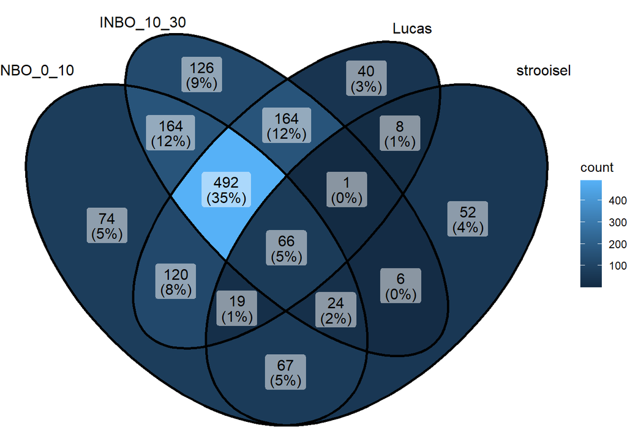

```r
tidy_physeq_srs %>%
  tidytacos::tacoplot_venn(Protocol2)
```

Unieke en gedeelde taxa per Land_use:

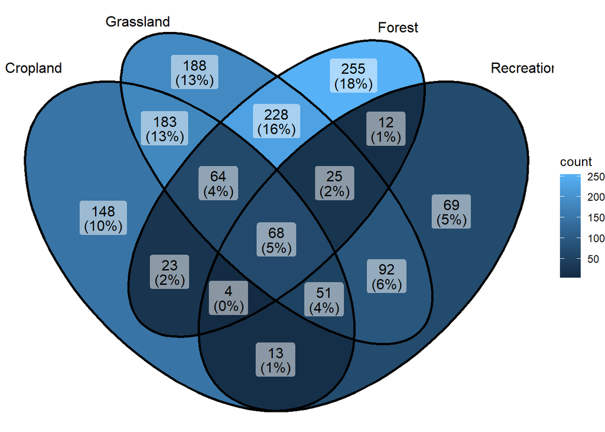

```r
tidy_physeq_srs %>%
  tidytacos::tacoplot_venn(Land_use)
```

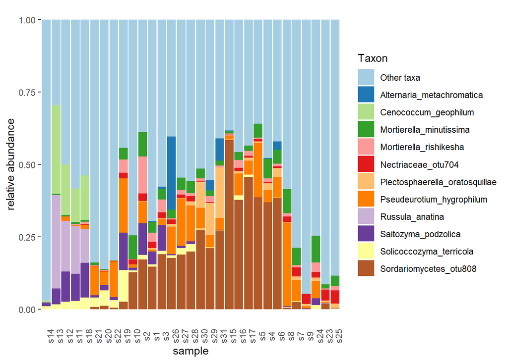

```r
tidy_physeq_srs %>%
  tidytacos::tacoplot_stack()
```

```r
# Create a new combined column
combined_column <- paste(sample_data(physeq_rarefied)$Land_use, sample_data(physeq_rarefied)$Protocol2, sep = "_")

# Add the new combined column to the sample metadata with the desired name
sample_data(physeq_rarefied)$Land_use_Protocol2 <- combined_column

# Update the phyloseq object with the modified sample data
physeq_rarefied <- merge_phyloseq(physeq_rarefied, sample_data(physeq_rarefied))


if (system(command = "which ktImportText",  intern = FALSE, ignore.stderr = TRUE,  ignore.stdout = TRUE) != 1) {
  psadd::plot_krona(physeq_rarefied, "ejp_Olig01_fungi_rar_Species_alle_stalen_Land_use_per_Protocol2", "Land_use_Protocol2", trim = T)
}
```

```r
tidy_physeq_srs %>%
  tidytacos::tacoplot_stack(x = Land_use)
```

```r
tidy_physeq_srs %>%
  tidytacos::tacoplot_stack(x = Protocol2)
```

## 3.5 Alfa-diversiteit

### 3.5.1 Regressiemodel met correctie voor totaal aantal reads

Het geobserveerde aantal taxa neemt toe met het aantal reads in een staal:

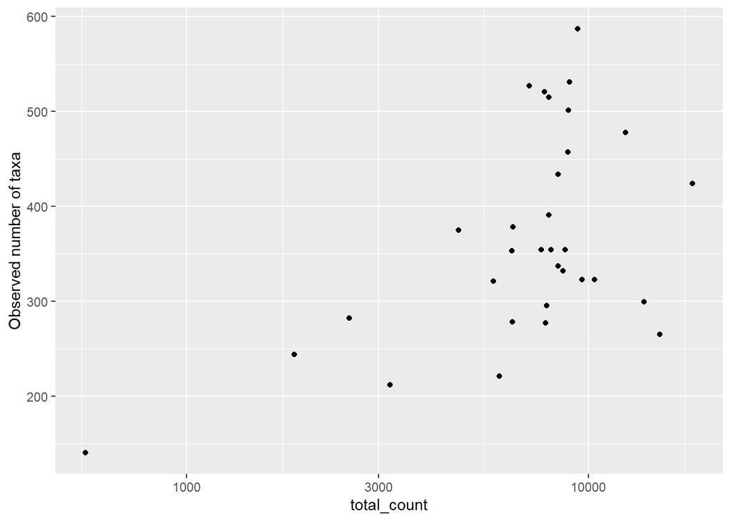

```r
tidy_physeq_nonrarefied_merged$samples %>%
  filter(total_count > 0) %>%
  ggplot(
    aes(x = total_count, y = observed)) +
  geom_point() +
  scale_x_log10() +
  labs(y = "Observed number of taxa")
```

We modelleren de soortenrijkdom als een Negatief Binomiaal model omdat we verwachten dat deze data overdispersie vertonen ten opzichte van een Poisson verdeling (waar de veronderstelling is dat de variantie gelijk aan het gemiddelde).

```r
samples_totcount_10k <- tidy_physeq$samples %>%
  filter(total_count > 1e+4)

form_fungi_richness <- formula(
  observed ~
    log(total_count)
  + Land_use
  + Protocol2
  + Land_use:Protocol2
  + (1 | Locatie)
  )

m_fungi_richness <- glmmTMB::glmmTMB(
  formula = form_fungi_richness,
  data = samples_totcount_10k,
  family = glmmTMB::nbinom2())
```

```r
performance::check_model(m_fungi_richness)
```

```r
summary(m_fungi_richness)
```

```r
car::Anova(m_fungi_richness)
```

Zoals te verwachten, is het belangrijk om te corrigeren voor het totaal aantal reads:

```r
marginaleffects::plot_predictions(
  m_fungi_richness,
  condition = c("total_count"),
  vcov = vcov(m_fungi_richness)) +
  labs(y = "Voorspeld aantal taxa") +
  scale_x_log10()
```

We kunnen nu predicties maken van soortenrijkdom waarbij we controleren voor het totaal aantal reads in een staal:

```r
marginaleffects::plot_predictions(
  m_fungi_richness,
  condition = c("Land_use", "Protocol2"),
  vcov = vcov(m_fungi_richness),
  re.form = NA,
  type = "response") +
  labs(y = "Voorspelde aantal taxa")
```

### 3.5.2 Rarefaction analyse

Dit is een alternatief voor voorgaande analyse. Schatting van de soortenrijkdom via rarefaction analyse.

```r
sam_new <- data.frame(sample_data(physeq_nonrarefied_merged))


estimated_Species_richness <- vegan::rarefy(
  veganobject_physeq_nonrarefied_merged,
  min(sample_sums(physeq_nonrarefied_merged)),
  se = TRUE,
  MARGIN = 1)


true_rarefaction_results <- cbind(
  sam_new %>% select(Name, Protocol2, Land_use),
  est = estimated_Species_richness["S", ],
  se = estimated_Species_richness["se", ]) %>%
  as_tibble() %>%
  mutate(est_lower = est - 2 * se,
         est_upper = est + 2 * se)
```

```r
glimpse(true_rarefaction_results)
```

```
## Rows: 32
## Columns: 7
## $ Name      <chr> "Bredene_0_10", "Bredene_10_30", "Bredene_Lucas", "Burdinne_…
## $ Protocol2 <chr> "INBO_0_10", "INBO_10_30", "Lucas", "INBO_0_10", "INBO_10_30…
## $ Land_use  <chr> "Cropland", "Cropland", "Cropland", "Cropland", "Cropland", …
## $ est       <dbl> 94.24132, 88.46469, 108.91126, 94.27029, 81.86430, 92.39959,…
## $ se        <dbl> 5.867407, 5.755242, 6.308663, 5.572965, 5.625612, 5.707793, …
## $ est_lower <dbl> 82.50651, 76.95421, 96.29393, 83.12436, 70.61307, 80.98400, …
## $ est_upper <dbl> 105.97614, 99.97517, 121.52859, 105.41621, 93.11552, 103.815…
```

```r
# verwijder gevallen waar se te klein is of nul is
true_rarefaction_results <- true_rarefaction_results %>%
  filter(se > 0.1)
```

```r
library(brms)
form_rarefaction <- bf(
  est | se(se, sigma = TRUE) ~
  + Land_use
  + Protocol2
  + Land_use:Protocol2
  + (1 | Name) # Moet dit Name zijn zoals bij Inse01?
)

m_rarefaction <- brm(
  formula = form_rarefaction,
  data = true_rarefaction_results,
  family = gaussian())
summary(m_rarefaction)
```

```
##  Family: gaussian
##   Links: mu = identity; sigma = identity
## Formula: est | se(se, sigma = TRUE) ~ +Land_use + Protocol2 + Land_use:Protocol2 + (1 | Name)
##    Data: true_rarefaction_results (Number of observations: 31)
##   Draws: 4 chains, each with iter = 2000; warmup = 1000; thin = 1;
##          total post-warmup draws = 4000
##
## Group-Level Effects:
## ~Name (Number of levels: 31)
##               Estimate Est.Error l-95% CI u-95% CI Rhat Bulk_ESS Tail_ESS
## sd(Intercept)    12.16      4.95     2.73    20.51 1.25       12       31
##
## Population-Level Effects:
##                                           Estimate  Est.Error    l-95% CI
## Intercept                                    83.81       8.82       63.69
## Land_useForest                               63.42      16.86       35.06
## Land_useGrassland                            44.57      13.51       19.24
## Land_useRecreation                           11.20      20.40      -24.74
## Protocol2INBO_10_30                          11.54      10.94       -6.39
## Protocol2Lucas                               13.65      13.67      -15.27
## Protocol2strooisel                       -69847.04  162945.40  -418057.55
## Land_useForest:Protocol2INBO_10_30          -56.00      21.16      -95.14
## Land_useGrassland:Protocol2INBO_10_30         0.81      17.98      -37.40
## Land_useRecreation:Protocol2INBO_10_30       31.83      28.84      -27.05
## Land_useForest:Protocol2Lucas               -65.73      23.62     -113.09
## Land_useGrassland:Protocol2Lucas             -6.26      19.17      -50.21
## Land_useRecreation:Protocol2Lucas             2.83      32.66      -66.71
## Land_useForest:Protocol2strooisel         69881.82  162937.41  -195002.04
## Land_useGrassland:Protocol2strooisel     527815.77 2231119.81 -1967081.34
## Land_useRecreation:Protocol2strooisel  -2040729.32 2215211.25 -8812064.86
##                                          u-95% CI Rhat Bulk_ESS Tail_ESS
## Intercept                                   99.49 1.41        9       25
## Land_useForest                              94.01 1.47        8       43
## Land_useGrassland                           74.66 1.34       10       35
## Land_useRecreation                          55.74 1.38       10       36
## Protocol2INBO_10_30                         33.68 1.25       12       70
## Protocol2Lucas                              41.32 1.33       10       31
## Protocol2strooisel                      195068.34 3.03        5       13
## Land_useForest:Protocol2INBO_10_30         -16.03 1.31       10       28
## Land_useGrassland:Protocol2INBO_10_30       34.12 1.19       17       79
## Land_useRecreation:Protocol2INBO_10_30      91.73 1.29       11       32
## Land_useForest:Protocol2Lucas              -15.48 1.51        7       19
## Land_useGrassland:Protocol2Lucas            27.85 1.15       21       27
## Land_useRecreation:Protocol2Lucas           71.04 1.34       10       16
## Land_useForest:Protocol2strooisel       418128.85 3.03        5       13
## Land_useGrassland:Protocol2strooisel   5813340.66 2.20        5       20
## Land_useRecreation:Protocol2strooisel   588414.38 1.45        9       15
##
## Family Specific Parameters:
##       Estimate Est.Error l-95% CI u-95% CI Rhat Bulk_ESS Tail_ESS
## sigma    14.02      6.26     4.94    26.62 1.83        6       40
##
## Draws were sampled using sampling(NUTS). For each parameter, Bulk_ESS
## and Tail_ESS are effective sample size measures, and Rhat is the potential
## scale reduction factor on split chains (at convergence, Rhat = 1).
```

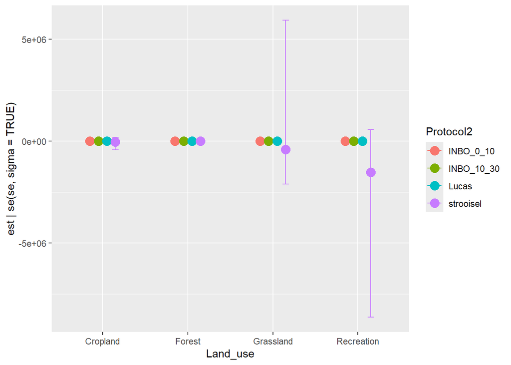

```r
conditional_effects(
  m_rarefaction,
    effects = c("Land_use:Protocol2"),
  re.form = NA)
```

## 3.6 OTU counts

per phylum

```r
# Count OTUs per Phylum
tax_table(physeq_srs) %>%
  as.data.frame() %>%
  as_tibble() %>%
  group_by(Phylum) %>%
  summarise(OTU_Count = n()) %>%
  kable()
```

| Phylum | OTU_Count |
| --- | --- |
| Ascomycota | 739 |
| Basidiobolomycota | 2 |
| Basidiomycota | 255 |
| Blastocladiomycota | 3 |
| Chytridiomycota | 32 |
| Fungi_otu1003 | 1 |
| Fungi_otu1014 | 1 |
| Fungi_otu1050 | 1 |
| Fungi_otu1068 | 1 |
| Fungi_otu1071 | 1 |
| Fungi_otu1097 | 1 |
| Fungi_otu110 | 1 |
| Fungi_otu1142 | 1 |
| Fungi_otu1163 | 1 |
| Fungi_otu1179 | 1 |
| Fungi_otu1210 | 1 |
| Fungi_otu1243 | 1 |
| Fungi_otu1256 | 1 |
| Fungi_otu1294 | 1 |
| Fungi_otu1312 | 1 |
| Fungi_otu132 | 1 |
| Fungi_otu1324 | 1 |
| Fungi_otu1327 | 1 |
| Fungi_otu135 | 1 |
| Fungi_otu1368 | 1 |
| Fungi_otu1394 | 1 |
| Fungi_otu1413 | 1 |
| Fungi_otu1415 | 1 |
| Fungi_otu1436 | 1 |
| Fungi_otu1441 | 1 |

[output cut: 142 more lines]

per class

```r
# Count OTUs per Class
tax_table(physeq_srs) %>%
  as.data.frame() %>%
  as_tibble() %>%
  group_by(Class) %>%
  summarise(OTU_Count = n()) %>%
  kable()
```

| Class | OTU_Count |
| --- | --- |
| Agaricomycetes | 166 |
| Agaricostilbomycetes | 2 |
| Archaeosporomycetes | 3 |
| Ascomycota_otu1070 | 1 |
| Ascomycota_otu1145 | 1 |
| Ascomycota_otu1168 | 1 |
| Ascomycota_otu1214 | 1 |
| Ascomycota_otu1257 | 1 |
| Ascomycota_otu1321 | 1 |
| Ascomycota_otu1346 | 1 |
| Ascomycota_otu136 | 1 |
| Ascomycota_otu1403 | 1 |
| Ascomycota_otu1456 | 1 |
| Ascomycota_otu1484 | 1 |
| Ascomycota_otu1532 | 1 |
| Ascomycota_otu1593 | 1 |
| Ascomycota_otu1650 | 1 |
| Ascomycota_otu1898 | 1 |
| Ascomycota_otu1937 | 1 |
| Ascomycota_otu1939 | 1 |
| Ascomycota_otu1976 | 1 |
| Ascomycota_otu1985 | 1 |
| Ascomycota_otu1995 | 1 |
| Ascomycota_otu2096 | 1 |
| Ascomycota_otu2168 | 1 |
| Ascomycota_otu2205 | 1 |
| Ascomycota_otu2360 | 1 |
| Ascomycota_otu246 | 1 |
| Ascomycota_otu253 | 1 |
| Ascomycota_otu2777 | 1 |

[output cut: 338 more lines]

per order

```r
# Count OTUs per order
tax_table(physeq_srs) %>%
  as.data.frame() %>%
  as_tibble() %>%
  group_by(Order) %>%
  summarise(OTU_Count = n()) %>%
  kable()
```

| Order | OTU_Count |
| --- | --- |
| Acrospermales | 2 |
| Agaricales | 80 |
| Agaricomycetes_otu1115 | 1 |
| Agaricomycetes_otu1469 | 1 |
| Agaricomycetes_otu2310 | 1 |
| Agaricomycetes_otu2793 | 1 |
| Agaricomycetes_otu3310 | 1 |
| Agaricomycetes_otu3472 | 1 |
| Agaricomycetes_otu4 | 1 |
| Agaricomycetes_otu4189 | 1 |
| Agaricomycetes_otu4225 | 1 |
| Agaricomycetes_otu5188 | 1 |
| Agaricomycetes_otu53 | 1 |
| Agaricomycetes_otu87 | 1 |
| Agaricostilbales | 2 |
| Archaeosporales | 3 |
| Ascomycota_otu1070 | 1 |
| Ascomycota_otu1145 | 1 |
| Ascomycota_otu1168 | 1 |
| Ascomycota_otu1214 | 1 |
| Ascomycota_otu1257 | 1 |
| Ascomycota_otu1321 | 1 |
| Ascomycota_otu1346 | 1 |
| Ascomycota_otu136 | 1 |
| Ascomycota_otu1403 | 1 |
| Ascomycota_otu1456 | 1 |
| Ascomycota_otu1484 | 1 |
| Ascomycota_otu1532 | 1 |
| Ascomycota_otu1593 | 1 |
| Ascomycota_otu1650 | 1 |

[output cut: 457 more lines]

per family

```r
# Count OTUs per family
tax_table(physeq_srs) %>%
  as.data.frame() %>%
  as_tibble() %>%
  group_by(Family) %>%
  summarise(OTU_Count = n()) %>%
  kable()
```

| Family | OTU_Count |
| --- | --- |
| Acrospermales_fam_Incertae_sedis | 2 |
| Agaricaceae | 1 |
| Agaricales_otu1390 | 1 |
| Agaricales_otu1409 | 1 |
| Agaricales_otu1518 | 1 |
| Agaricales_otu1551 | 1 |
| Agaricales_otu1663 | 1 |
| Agaricales_otu2065 | 1 |
| Agaricales_otu3176 | 1 |
| Agaricales_otu3771 | 1 |
| Agaricales_otu3926 | 1 |
| Agaricales_otu4054 | 1 |
| Agaricales_otu4111 | 1 |
| Agaricales_otu4132 | 1 |
| Agaricales_otu536 | 1 |
| Agaricales_otu731 | 1 |
| Agaricomycetes_otu1115 | 1 |
| Agaricomycetes_otu1469 | 1 |
| Agaricomycetes_otu2310 | 1 |
| Agaricomycetes_otu2793 | 1 |
| Agaricomycetes_otu3310 | 1 |
| Agaricomycetes_otu3472 | 1 |
| Agaricomycetes_otu4 | 1 |
| Agaricomycetes_otu4189 | 1 |
| Agaricomycetes_otu4225 | 1 |
| Agaricomycetes_otu5188 | 1 |
| Agaricomycetes_otu53 | 1 |
| Agaricomycetes_otu87 | 1 |
| Agaricostilbales_otu4975 | 1 |
| Alphamycetaceae | 2 |

[output cut: 812 more lines]

Per genus

```r
tax_table(physeq_srs) %>%
  as.data.frame() %>%
  group_by(Genus) %>%
  summarise(OTU_Count = n()) %>%
  arrange(desc(OTU_Count)) %>%
  kable()
```

| Genus | OTU_Count |
| --- | --- |
| Mortierella | 35 |
| Penicillium | 30 |
| Trichoderma | 16 |
| Absidia | 11 |
| Oidiodendron | 10 |
| Acremonium | 8 |
| Cortinarius | 8 |
| Inocybe | 7 |
| Mucor | 7 |
| Podospora | 7 |
| Syncephalis | 7 |
| Ascobolus | 6 |
| Aspergillus | 6 |
| Cladophialophora | 6 |
| Talaromyces | 6 |
| Tomentella | 6 |
| Chaetomium | 5 |
| Chaetosphaeria | 5 |
| Laccaria | 5 |
| Mycena | 5 |
| Umbelopsis | 5 |
| Apiotrichum | 4 |
| Cladorrhinum | 4 |
| Fusarium | 4 |
| Serendipita | 4 |
| Tolypocladium | 4 |
| Vishniacozyma | 4 |
| Alternaria | 3 |
| Amanita | 3 |
| Beauveria | 3 |

[output cut: 1112 more lines]

Per Species (check of er Species zijn met meer dan 1 OTU)

```r
tax_table(physeq_srs) %>%
  as.data.frame() %>%
  group_by(Species) %>%
  summarise(OTU_Count = n()) %>%
  filter(OTU_Count > 1) %>%
  kable()
```

| Species | OTU_Count |
| --- | --- |

## 3.7 Read counts

Overzicht van som van reads per phylum:

```r
tidy_physeq %>%
  tidytacos::aggregate_taxa(rank = "Phylum") %>%
  tidytacos::everything() %>%
  group_by(phylum) %>%
  summarise(read_counts = sum(count)) %>%
  arrange(desc(read_counts)) %>%
  kable()
```

Overzicht van som van reads per class:

```r
tidy_physeq %>%
  tidytacos::aggregate_taxa(rank = "class") %>%
  tidytacos::everything() %>%
  group_by(class) %>%
  summarise(read_counts = sum(count)) %>%
  arrange(desc(read_counts)) %>%
  kable()
```

Overzicht van som van reads per family:

```r
tidy_physeq %>%
  tidytacos::aggregate_taxa(rank = "family") %>%
  tidytacos::everything() %>%
  group_by(family) %>%
  summarise(read_counts = sum(count)) %>%
  arrange(desc(read_counts)) %>%
  kable()
```

Overzicht van som van reads per genus:

```r
tidy_physeq %>%
  tidytacos::aggregate_taxa(rank = "genus") %>%
  tidytacos::everything() %>%
  group_by(genus) %>%
  summarise(read_counts = sum(count)) %>%
  arrange(desc(read_counts)) %>%
  kable()
```

Overzicht van som van reads per species:

```r
tidy_physeq %>%
  tidytacos::aggregate_taxa(rank = "species") %>%
  tidytacos::everything() %>%
  group_by(species) %>%
  summarise(read_counts = sum(count)) %>%
  arrange(desc(read_counts)) %>%
  kable()
```

## 3.8 Ordinatie

```r
ordmat <- psotu2veg(physeq_rarefied)

all(colSums(ordmat) > 0)
all(rowSums(ordmat) > 0)
all(ordmat >= 0)

ordmat <- decostand(ordmat, method = "rclr")

samples <- sample_data(physeq_rarefied) %>%
  as.data.frame() %>%
  as_tibble()

rda <- rda(ordmat)

biplot(rda)
```

```r
# Perform CLR transformation
clr_physeq_rarefied <- transform(physeq_rarefied, "clr")

# Calculate Bray distance matrix based on the CLR-transformed data
bray_distance <- distance(physeq, method = "bray")

# Perform PCoA
pcoa_result <- ordinate(physeq, method = "PCoA", distance = "bray")

# Create the ordination plot with color based on land_use and shape
# based on Protocol2
plot_ordination(physeq, pcoa_result, type = "samples",
                color = "Land_use", shape = "Protocol2") +
  theme_minimal()
```